# Project RMD

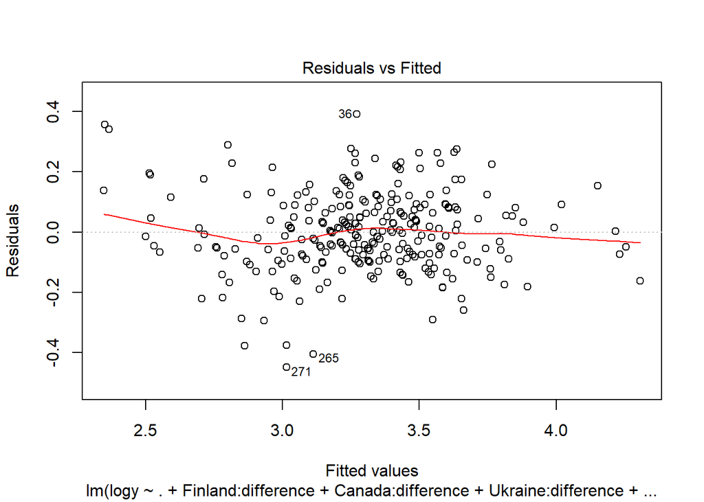

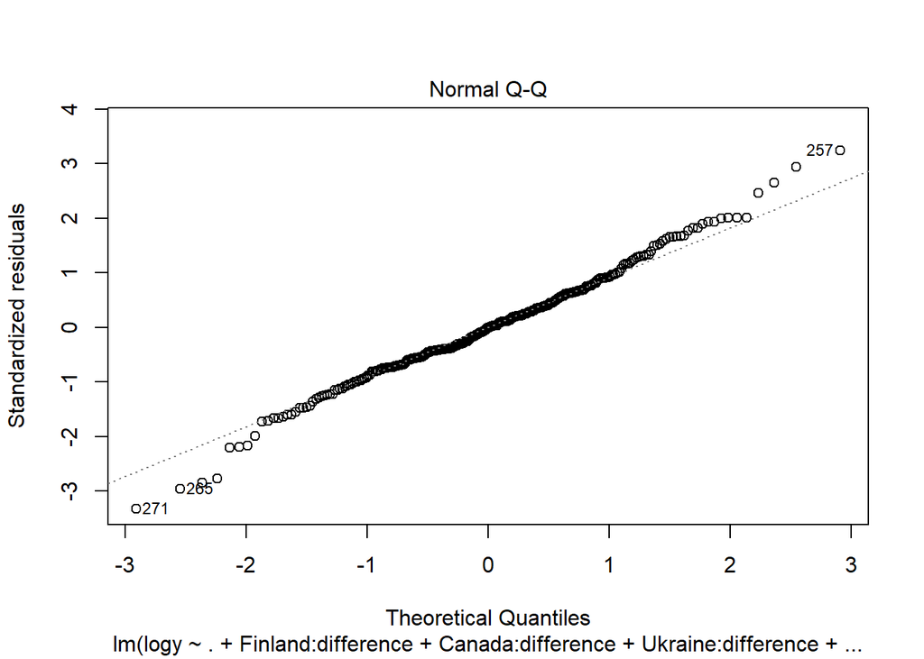

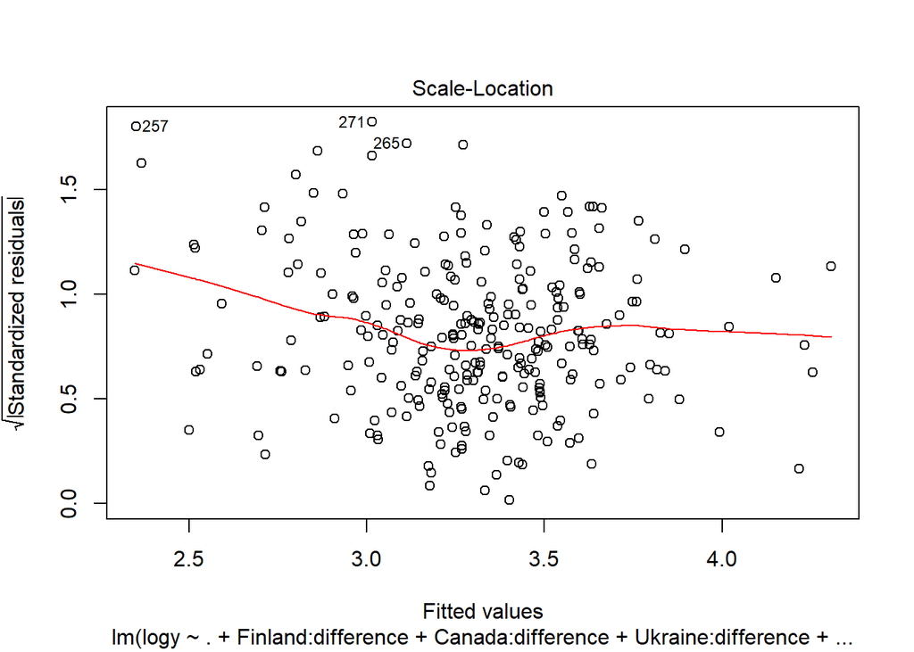

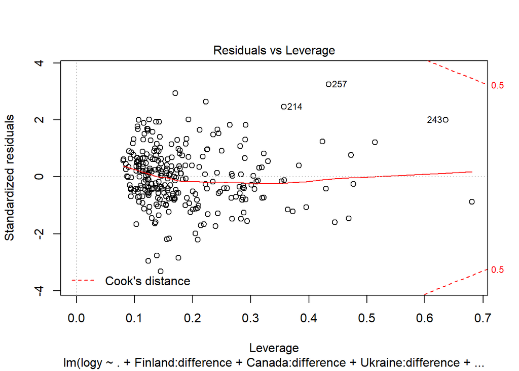

```r
plot(fit.lm.8)
```

Remove the standard deviation rates, keep them out b/c of multicollinearity with other quarter statistics.

```r
fit.lm.9 = lm(logy ~ .+
                Finland:difference+
                Canada:difference+
                Ukraine:difference+
                Switzerland:difference+
                Denmark:difference+
                Belgium:difference+
                Ireland:difference+
                UK:difference+
                Germany:difference+
                France:difference+
                NZ:difference+
                US:difference+
                Japan:difference+
                Spain:difference+
                Australia:difference+
                Mexico:difference+
                India:difference+
                Singapore:difference+
                Russia:difference
                - difference
                - Yards
                -Sweden
                -Russia
                -Finland
                -Canada
                -Ukraine
                -Switzerland
                -Denmark
                -Belgium
                -Ireland
                -UK
                -Germany
                -France
                -NZ
                -US
                -Japan
                -Spain
                -Australia
                -Mexico
                -India
                -Singapore
                -Belarus
                - rate_sd1
                - rate_sd2
                -rate_sd3
                -rate_sd4
              ,data = df.filtered.2)
summary(fit.lm.9)
```

```
##
## Call:
## lm(formula = logy ~ . + Finland:difference + Canada:difference +
##     Ukraine:difference + Switzerland:difference + Denmark:difference +
##     Belgium:difference + Ireland:difference + UK:difference +
##     Germany:difference + France:difference + NZ:difference +
##     US:difference + Japan:difference + Spain:difference + Australia:difference +
##     Mexico:difference + India:difference + Singapore:difference +
##     Russia:difference - difference - Yards - Sweden - Russia -
##     Finland - Canada - Ukraine - Switzerland - Denmark - Belgium -
##     Ireland - UK - Germany - France - NZ - US - Japan - Spain -
##     Australia - Mexico - India - Singapore - Belarus - rate_sd1 -
##     rate_sd2 - rate_sd3 - rate_sd4, data = df.filtered.2)
##
## Residuals:
##      Min       1Q   Median       3Q      Max
## -0.44738 -0.08299 -0.00267  0.08664  0.41882
##
## Coefficients:
##                           Estimate Std. Error t value Pr(>|t|)
## (Intercept)              3.048e+00  3.206e-01   9.509  < 2e-16 ***
## avg_rate_q1             -8.511e-05  4.157e-04  -0.205  0.83796
## avg_rate_q2             -6.247e-04  6.815e-04  -0.917  0.36029
## avg_rate_q3             -1.301e-03  6.163e-04  -2.111  0.03584 *
## avg_rate_q4             -1.829e-03  3.896e-04  -4.694 4.61e-06 ***
## median_rate_q1           2.903e-04  2.927e-04   0.992  0.32226
## median_rate_q2          -1.168e-04  4.253e-04  -0.275  0.78377
## median_rate_q3           3.887e-04  3.547e-04   1.096  0.27426
## median_rate_q4          -3.052e-04  2.530e-04  -1.206  0.22894
## sd_q1                   -6.259e-03  7.073e-04  -8.848 2.40e-16 ***
## sd_q2                   -6.966e-04  6.070e-04  -1.148  0.25233
## sd_q3                   -4.064e-03  6.286e-04  -6.465 6.00e-10 ***
## sd_q4                   -2.471e-03  4.223e-04  -5.852 1.66e-08 ***
## avg_sec_q1              -9.320e-04  4.144e-04  -2.249  0.02546 *
## avg_sec_q2              -2.903e-05  4.200e-04  -0.069  0.94495
## avg_sec_q3              -4.664e-04  3.696e-04  -1.262  0.20830
## avg_sec_q4               3.376e-04  3.772e-04   0.895  0.37173
## median_sec_q1            9.697e-04  3.724e-04   2.604  0.00982 **
## median_sec_q2           -5.360e-05  3.514e-04  -0.153  0.87889
## median_sec_q3           -8.068e-05  2.938e-04  -0.275  0.78386
```

[output cut: 18 more lines]

```
## difference:NZ1          -1.219e-02  9.357e-03  -1.303  0.19398
## difference:US1          -1.022e-02  1.241e-02  -0.823  0.41124
## difference:Japan1       -4.338e-03  5.289e-03  -0.820  0.41303
## difference:Spain1       -1.325e-02  1.276e-02  -1.038  0.30028
## difference:Australia1   -1.146e-02  9.055e-03  -1.266  0.20686
## difference:Mexico1      -1.892e-02  1.354e-02  -1.397  0.16362
## difference:India1       -7.029e-03  8.815e-03  -0.797  0.42606
## difference:Singapore1   -7.081e-03  5.233e-03  -1.353  0.17730
## difference:Russia1      -3.432e-04  4.514e-03  -0.076  0.93946
## ---
## Signif. codes:  0 '***' 0.001 '**' 0.01 '*' 0.05 '.' 0.1 ' ' 1
##
## Residual standard error: 0.148 on 230 degrees of freedom
## Multiple R-squared:  0.8531, Adjusted R-squared:  0.8237
## F-statistic: 29.04 on 46 and 230 DF,  p-value: < 2.2e-16
```

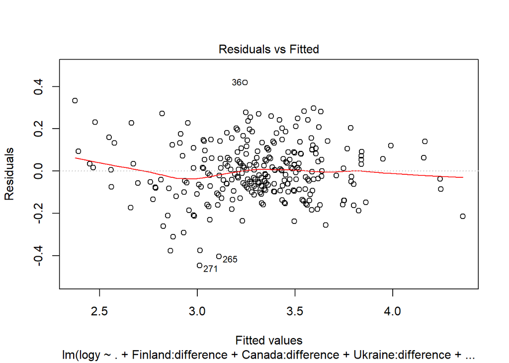

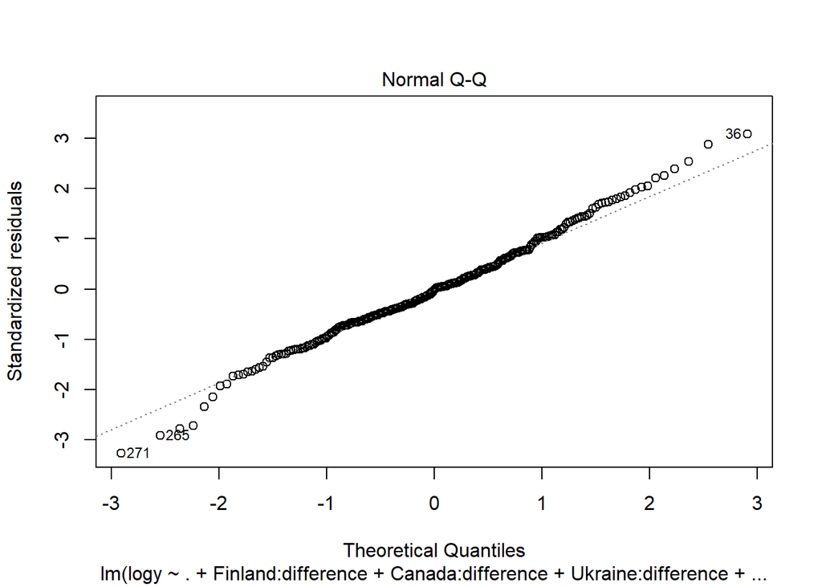

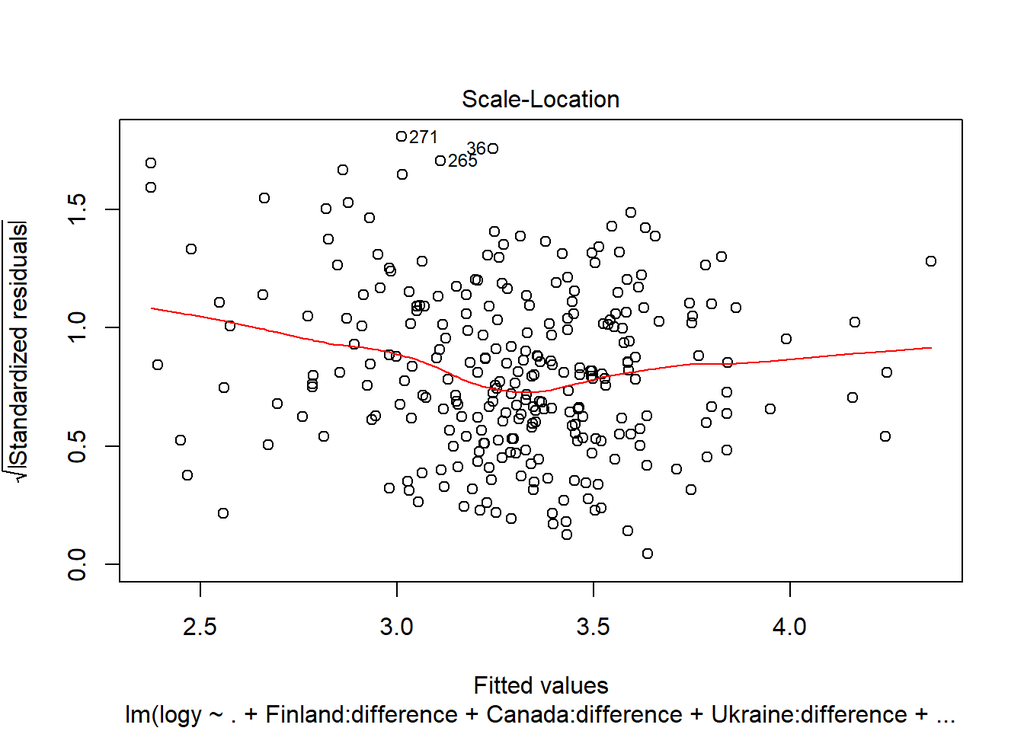

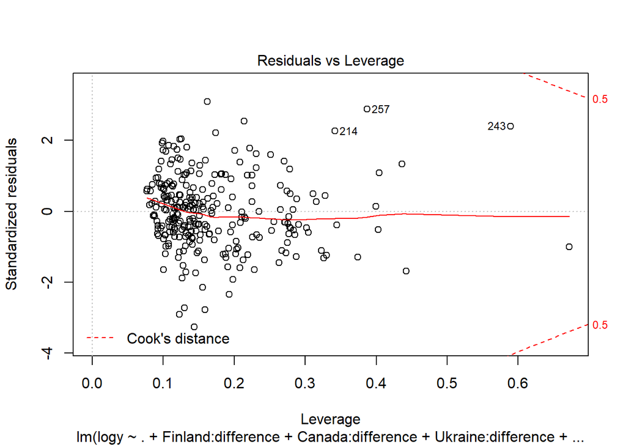

```r
plot(fit.lm.9)
```

```r
anova(fit.lm.9, fit.lm.8)
```

```
## Analysis of Variance Table
##
## Model 1: logy ~ rate_sd1 + rate_sd2 + rate_sd3 + rate_sd4 + avg_rate_q1 +
##     avg_rate_q2 + avg_rate_q3 + avg_rate_q4 + median_rate_q1 +
##     median_rate_q2 + median_rate_q3 + median_rate_q4 + sd_q1 +
##     sd_q2 + sd_q3 + sd_q4 + avg_sec_q1 + avg_sec_q2 + avg_sec_q3 +
##     avg_sec_q4 + median_sec_q1 + median_sec_q2 + median_sec_q3 +
##     median_sec_q4 + range_q1 + range_q2 + range_q3 + range_q4 +
##     difference + Australia + Belarus + Belgium + Canada + Denmark +
##     Finland + France + Germany + India + Ireland + Japan + Mexico +
##     NZ + Russia + Singapore + Spain + Sweden + Switzerland +
##     Ukraine + UK + US + Yards + MaxSeconds + MinSeconds + Finland:difference +
##     Canada:difference + Ukraine:difference + Switzerland:difference +
##     Denmark:difference + Belgium:difference + Ireland:difference +
##     UK:difference + Germany:difference + France:difference +
##     NZ:difference + US:difference + Japan:difference + Spain:difference +
##     Australia:difference + Mexico:difference + India:difference +
##     Singapore:difference + Russia:difference - difference - Yards -
##     Sweden - Russia - Finland - Canada - Ukraine - Switzerland -
##     Denmark - Belgium - Ireland - UK - Germany - France - NZ -
##     US - Japan - Spain - Australia - Mexico - India - Singapore -
##     Belarus - rate_sd1 - rate_sd2 - rate_sd3 - rate_sd4
## Model 2: logy ~ rate_sd1 + rate_sd2 + rate_sd3 + rate_sd4 + avg_rate_q1 +
##     avg_rate_q2 + avg_rate_q3 + avg_rate_q4 + median_rate_q1 +
##     median_rate_q2 + median_rate_q3 + median_rate_q4 + sd_q1 +
##     sd_q2 + sd_q3 + sd_q4 + avg_sec_q1 + avg_sec_q2 + avg_sec_q3 +
##     avg_sec_q4 + median_sec_q1 + median_sec_q2 + median_sec_q3 +
##     median_sec_q4 + range_q1 + range_q2 + range_q3 + range_q4 +
##     difference + Australia + Belarus + Belgium + Canada + Denmark +
##     Finland + France + Germany + India + Ireland + Japan + Mexico +
##     NZ + Russia + Singapore + Spain + Sweden + Switzerland +
##     Ukraine + UK + US + Yards + MaxSeconds + MinSeconds + Finland:difference +
##     Canada:difference + Ukraine:difference + Switzerland:difference +
##     Denmark:difference + Belgium:difference + Ireland:difference +
##     UK:difference + Germany:difference + France:difference +
##     NZ:difference + US:difference + Japan:difference + Spain:difference +
##     Australia:difference + Mexico:difference + India:difference +
##     Singapore:difference + Russia:difference - difference - Sweden -
##     Russia - Finland - Canada - Ukraine - Switzerland - Denmark -
##     Belgium - Ireland - UK - Germany - France - NZ - US - Japan -
##     Spain - Australia - Mexico - Yards - India - Singapore -
##     Belarus
##   Res.Df    RSS Df Sum of Sq      F  Pr(>F)
## 1    230 5.0407
## 2    226 4.8201  4   0.22057 2.5854 0.03787 *
## ---
## Signif. codes:  0 '***' 0.001 '**' 0.01 '*' 0.05 '.' 0.1 ' ' 1
```

Remove Median Rates.

```r
fit.lm.10 = lm(logy ~ .+
                Finland:difference+
                Canada:difference+
                Ukraine:difference+
                Switzerland:difference+
                Denmark:difference+
                Belgium:difference+
                Ireland:difference+
                UK:difference+
                Germany:difference+
                France:difference+
                NZ:difference+
                US:difference+
                Japan:difference+
                Spain:difference+
                Australia:difference+
                Mexico:difference+
                India:difference+
                Singapore:difference+
                Russia:difference
                - difference
                - Yards
                -Sweden
              - median_rate_q1
              - median_rate_q2
              - median_rate_q3
              - median_rate_q4
                -Russia
                -Finland
                -Canada
                -Ukraine
                -Switzerland
                -Denmark
                -Belgium
                -Ireland
                -UK
                -Germany
                -France
                -NZ
                -US
                -Japan
                -Spain
                -Australia
                -Mexico
                -India
                -Singapore
                -Belarus
                - rate_sd1
                - rate_sd2
                -rate_sd3
                -rate_sd4
              ,data = df.filtered.2)
summary(fit.lm.10)
```

```
##
## Call:
## lm(formula = logy ~ . + Finland:difference + Canada:difference +
##     Ukraine:difference + Switzerland:difference + Denmark:difference +
##     Belgium:difference + Ireland:difference + UK:difference +
##     Germany:difference + France:difference + NZ:difference +
##     US:difference + Japan:difference + Spain:difference + Australia:difference +
##     Mexico:difference + India:difference + Singapore:difference +
##     Russia:difference - difference - Yards - Sweden - median_rate_q1 -
##     median_rate_q2 - median_rate_q3 - median_rate_q4 - Russia -
##     Finland - Canada - Ukraine - Switzerland - Denmark - Belgium -
##     Ireland - UK - Germany - France - NZ - US - Japan - Spain -
##     Australia - Mexico - India - Singapore - Belarus - rate_sd1 -
##     rate_sd2 - rate_sd3 - rate_sd4, data = df.filtered.2)
##
## Residuals:
##      Min       1Q   Median       3Q      Max
## -0.46600 -0.08630 -0.00473  0.08506  0.40459
##
## Coefficients:
##                           Estimate Std. Error t value Pr(>|t|)
## (Intercept)              3.033e+00  3.187e-01   9.518  < 2e-16 ***
## avg_rate_q1              1.766e-04  3.439e-04   0.513  0.60811
## avg_rate_q2             -6.598e-04  6.379e-04  -1.034  0.30206
## avg_rate_q3             -9.845e-04  5.548e-04  -1.774  0.07729 .
## avg_rate_q4             -1.940e-03  3.454e-04  -5.616 5.52e-08 ***
## sd_q1                   -6.043e-03  6.936e-04  -8.712 5.54e-16 ***
## sd_q2                   -8.368e-04  5.902e-04  -1.418  0.15761
## sd_q3                   -4.054e-03  6.163e-04  -6.578 3.08e-10 ***
## sd_q4                   -2.543e-03  4.196e-04  -6.060 5.39e-09 ***
## avg_sec_q1              -1.003e-03  4.089e-04  -2.452  0.01493 *
## avg_sec_q2              -5.205e-05  4.188e-04  -0.124  0.90119
## avg_sec_q3              -3.474e-04  3.635e-04  -0.956  0.34022
## avg_sec_q4               3.163e-04  3.694e-04   0.856  0.39276
## median_sec_q1            1.007e-03  3.679e-04   2.737  0.00668 **
## median_sec_q2           -2.859e-05  3.507e-04  -0.082  0.93511
## median_sec_q3           -1.457e-04  2.894e-04  -0.503  0.61516
## median_sec_q4           -6.086e-05  2.720e-04  -0.224  0.82315
## range_q1                 2.394e-03  2.372e-04  10.092  < 2e-16 ***
## range_q2                 3.697e-04  1.950e-04   1.896  0.05923 .
```

[output cut: 15 more lines]

```
## difference:NZ1          -1.302e-02  9.253e-03  -1.407  0.16083
## difference:US1          -1.137e-02  1.224e-02  -0.929  0.35360
## difference:Japan1       -4.332e-03  5.255e-03  -0.824  0.41059
## difference:Spain1       -1.462e-02  1.259e-02  -1.161  0.24669
## difference:Australia1   -1.272e-02  8.895e-03  -1.429  0.15421
## difference:Mexico1      -2.053e-02  1.332e-02  -1.541  0.12472
## difference:India1       -8.195e-03  8.686e-03  -0.943  0.34640
## difference:Singapore1   -7.870e-03  5.189e-03  -1.517  0.13068
## difference:Russia1      -8.448e-04  4.489e-03  -0.188  0.85089
## ---
## Signif. codes:  0 '***' 0.001 '**' 0.01 '*' 0.05 '.' 0.1 ' ' 1
##
## Residual standard error: 0.1479 on 234 degrees of freedom
## Multiple R-squared:  0.8508, Adjusted R-squared:  0.824
## F-statistic: 31.76 on 42 and 234 DF,  p-value: < 2.2e-16
```

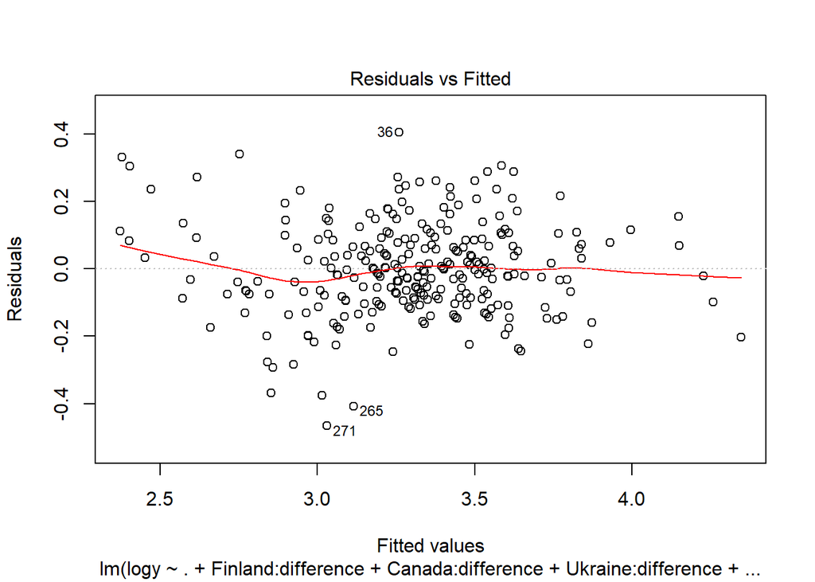

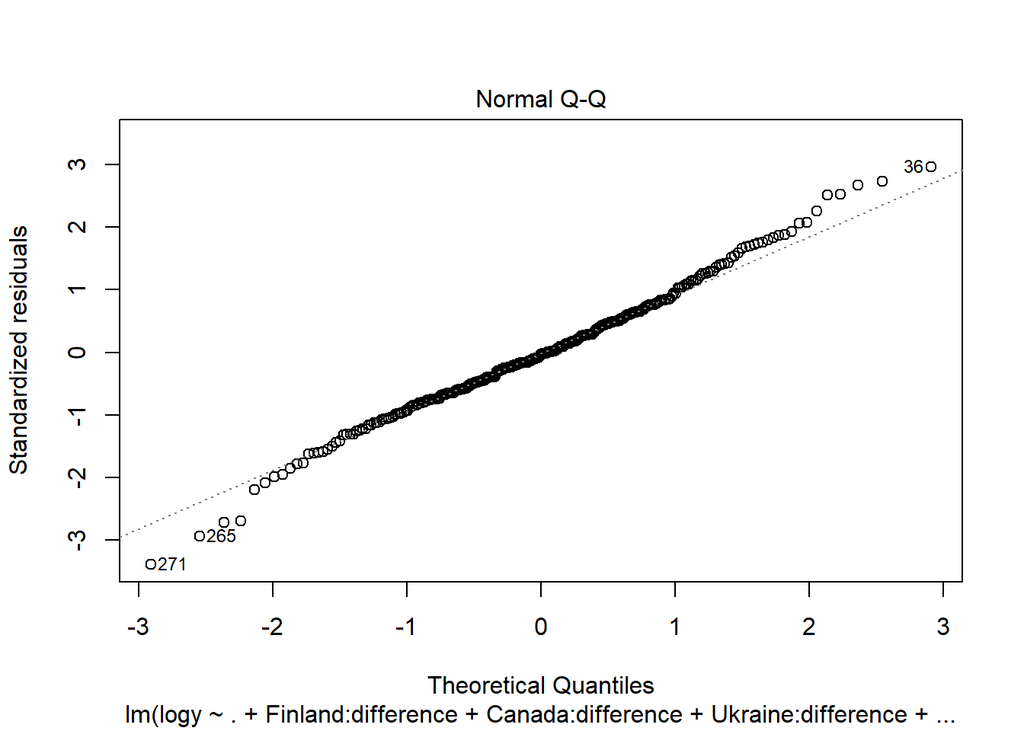

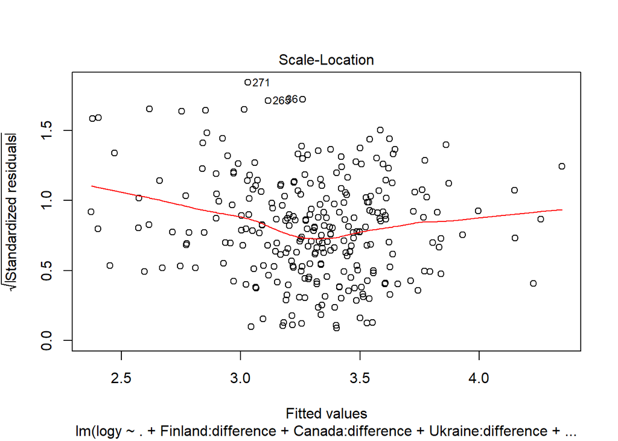

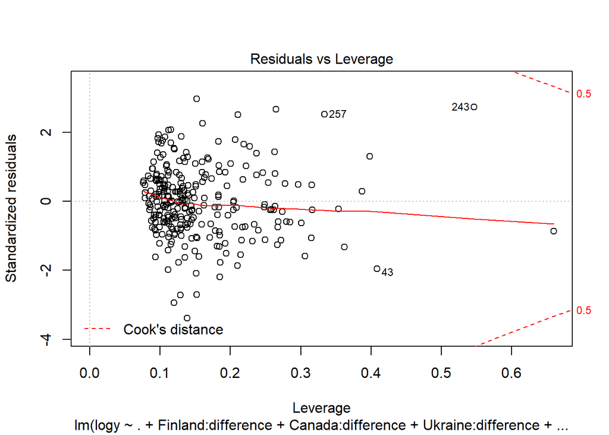

```r
plot(fit.lm.10)
```

```r
anova(fit.lm.9, fit.lm.10)
```

```
## Analysis of Variance Table
##
## Model 1: logy ~ rate_sd1 + rate_sd2 + rate_sd3 + rate_sd4 + avg_rate_q1 +
##     avg_rate_q2 + avg_rate_q3 + avg_rate_q4 + median_rate_q1 +
##     median_rate_q2 + median_rate_q3 + median_rate_q4 + sd_q1 +
##     sd_q2 + sd_q3 + sd_q4 + avg_sec_q1 + avg_sec_q2 + avg_sec_q3 +
##     avg_sec_q4 + median_sec_q1 + median_sec_q2 + median_sec_q3 +
##     median_sec_q4 + range_q1 + range_q2 + range_q3 + range_q4 +
##     difference + Australia + Belarus + Belgium + Canada + Denmark +
##     Finland + France + Germany + India + Ireland + Japan + Mexico +
##     NZ + Russia + Singapore + Spain + Sweden + Switzerland +
##     Ukraine + UK + US + Yards + MaxSeconds + MinSeconds + Finland:difference +
##     Canada:difference + Ukraine:difference + Switzerland:difference +
##     Denmark:difference + Belgium:difference + Ireland:difference +
##     UK:difference + Germany:difference + France:difference +
##     NZ:difference + US:difference + Japan:difference + Spain:difference +
##     Australia:difference + Mexico:difference + India:difference +
##     Singapore:difference + Russia:difference - difference - Yards -
##     Sweden - Russia - Finland - Canada - Ukraine - Switzerland -
##     Denmark - Belgium - Ireland - UK - Germany - France - NZ -
##     US - Japan - Spain - Australia - Mexico - India - Singapore -
##     Belarus - rate_sd1 - rate_sd2 - rate_sd3 - rate_sd4
## Model 2: logy ~ rate_sd1 + rate_sd2 + rate_sd3 + rate_sd4 + avg_rate_q1 +
##     avg_rate_q2 + avg_rate_q3 + avg_rate_q4 + median_rate_q1 +
##     median_rate_q2 + median_rate_q3 + median_rate_q4 + sd_q1 +
##     sd_q2 + sd_q3 + sd_q4 + avg_sec_q1 + avg_sec_q2 + avg_sec_q3 +
##     avg_sec_q4 + median_sec_q1 + median_sec_q2 + median_sec_q3 +
##     median_sec_q4 + range_q1 + range_q2 + range_q3 + range_q4 +
##     difference + Australia + Belarus + Belgium + Canada + Denmark +
##     Finland + France + Germany + India + Ireland + Japan + Mexico +
##     NZ + Russia + Singapore + Spain + Sweden + Switzerland +
##     Ukraine + UK + US + Yards + MaxSeconds + MinSeconds + Finland:difference +
##     Canada:difference + Ukraine:difference + Switzerland:difference +
##     Denmark:difference + Belgium:difference + Ireland:difference +
##     UK:difference + Germany:difference + France:difference +
##     NZ:difference + US:difference + Japan:difference + Spain:difference +
##     Australia:difference + Mexico:difference + India:difference +
##     Singapore:difference + Russia:difference - difference - Yards -
##     Sweden - median_rate_q1 - median_rate_q2 - median_rate_q3 -
##     median_rate_q4 - Russia - Finland - Canada - Ukraine - Switzerland -
##     Denmark - Belgium - Ireland - UK - Germany - France - NZ -
##     US - Japan - Spain - Australia - Mexico - India - Singapore -
##     Belarus - rate_sd1 - rate_sd2 - rate_sd3 - rate_sd4
##   Res.Df    RSS Df Sum of Sq      F Pr(>F)
## 1    230 5.0407
## 2    234 5.1217 -4 -0.081026 0.9243 0.4505
```

Remove Median Seconds.

```r
fit.lm.11 = lm(logy ~ .+
                Finland:difference+
                Canada:difference+
                Ukraine:difference+
                Switzerland:difference+
                Denmark:difference+
                Belgium:difference+
                Ireland:difference+
                UK:difference+
                Germany:difference+
                France:difference+
                NZ:difference+
                US:difference+
                Japan:difference+
                Spain:difference+
                Australia:difference+
                Mexico:difference+
                India:difference+
                Singapore:difference+
                Russia:difference
                - difference
                - Yards
                -Sweden
              - median_rate_q1
              - median_rate_q2
              - median_rate_q3
              - median_rate_q4
              - median_sec_q2
              - median_sec_q3
              - median_sec_q4
                -Russia
                -Finland
                -Canada
                -Ukraine
                -Switzerland
                -Denmark
                -Belgium
                -Ireland
                -UK
                -Germany
                -France
                -NZ
                -US
                -Japan
                -Spain
                -Australia
                -Mexico
                -India
                -Singapore
                -Belarus
                - rate_sd1
                - rate_sd2
                -rate_sd3
                -rate_sd4
              ,data = df.filtered.2)
summary(fit.lm.11)
```

```
##
## Call:
## lm(formula = logy ~ . + Finland:difference + Canada:difference +
##     Ukraine:difference + Switzerland:difference + Denmark:difference +
##     Belgium:difference + Ireland:difference + UK:difference +
##     Germany:difference + France:difference + NZ:difference +
##     US:difference + Japan:difference + Spain:difference + Australia:difference +
##     Mexico:difference + India:difference + Singapore:difference +
##     Russia:difference - difference - Yards - Sweden - median_rate_q1 -
##     median_rate_q2 - median_rate_q3 - median_rate_q4 - median_sec_q2 -
##     median_sec_q3 - median_sec_q4 - Russia - Finland - Canada -
##     Ukraine - Switzerland - Denmark - Belgium - Ireland - UK -
##     Germany - France - NZ - US - Japan - Spain - Australia -
##     Mexico - India - Singapore - Belarus - rate_sd1 - rate_sd2 -
##     rate_sd3 - rate_sd4, data = df.filtered.2)
##
## Residuals:
##      Min       1Q   Median       3Q      Max
## -0.47200 -0.08742 -0.00593  0.08717  0.40123
##
## Coefficients:
##                           Estimate Std. Error t value Pr(>|t|)
## (Intercept)              3.057e+00  3.135e-01   9.750  < 2e-16 ***
## avg_rate_q1              1.988e-04  3.302e-04   0.602  0.54762
## avg_rate_q2             -6.143e-04  6.170e-04  -0.996  0.32043
## avg_rate_q3             -9.901e-04  5.512e-04  -1.796  0.07371 .
## avg_rate_q4             -1.942e-03  3.396e-04  -5.718 3.24e-08 ***
## sd_q1                   -6.086e-03  6.772e-04  -8.986  < 2e-16 ***
## sd_q2                   -7.948e-04  5.725e-04  -1.388  0.16633
## sd_q3                   -4.091e-03  6.059e-04  -6.752 1.12e-10 ***
## sd_q4                   -2.535e-03  4.098e-04  -6.184 2.71e-09 ***
## avg_sec_q1              -1.011e-03  4.029e-04  -2.509  0.01278 *
## avg_sec_q2              -8.705e-05  1.915e-04  -0.455  0.64976
## avg_sec_q3              -5.128e-04  1.696e-04  -3.024  0.00277 **
## avg_sec_q4               2.401e-04  1.608e-04   1.493  0.13674
## median_sec_q1            1.019e-03  3.594e-04   2.834  0.00499 **
## range_q1                 2.402e-03  2.341e-04  10.257  < 2e-16 ***
## range_q2                 3.574e-04  1.907e-04   1.874  0.06218 .
## range_q3                 1.526e-03  2.183e-04   6.989 2.79e-11 ***
## range_q4                 1.024e-03  1.617e-04   6.333 1.20e-09 ***
```

[output cut: 13 more lines]

```
## difference:NZ1          -1.289e-02  9.189e-03  -1.403  0.16195
## difference:US1          -1.111e-02  1.214e-02  -0.915  0.36107
## difference:Japan1       -4.189e-03  5.212e-03  -0.804  0.42235
## difference:Spain1       -1.433e-02  1.250e-02  -1.147  0.25274
## difference:Australia1   -1.264e-02  8.828e-03  -1.432  0.15357
## difference:Mexico1      -2.021e-02  1.322e-02  -1.529  0.12768
## difference:India1       -8.319e-03  8.622e-03  -0.965  0.33559
## difference:Singapore1   -7.691e-03  5.140e-03  -1.496  0.13594
## difference:Russia1      -5.469e-04  4.418e-03  -0.124  0.90159
## ---
## Signif. codes:  0 '***' 0.001 '**' 0.01 '*' 0.05 '.' 0.1 ' ' 1
##
## Residual standard error: 0.1471 on 237 degrees of freedom
## Multiple R-squared:  0.8506, Adjusted R-squared:  0.826
## F-statistic: 34.59 on 39 and 237 DF,  p-value: < 2.2e-16
```

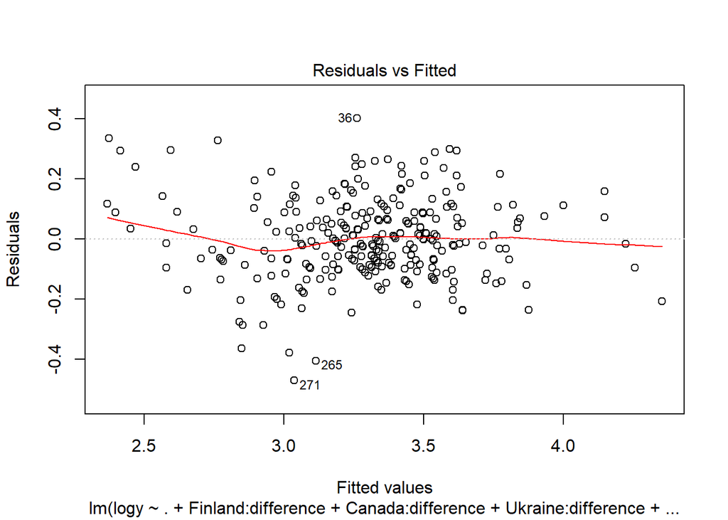

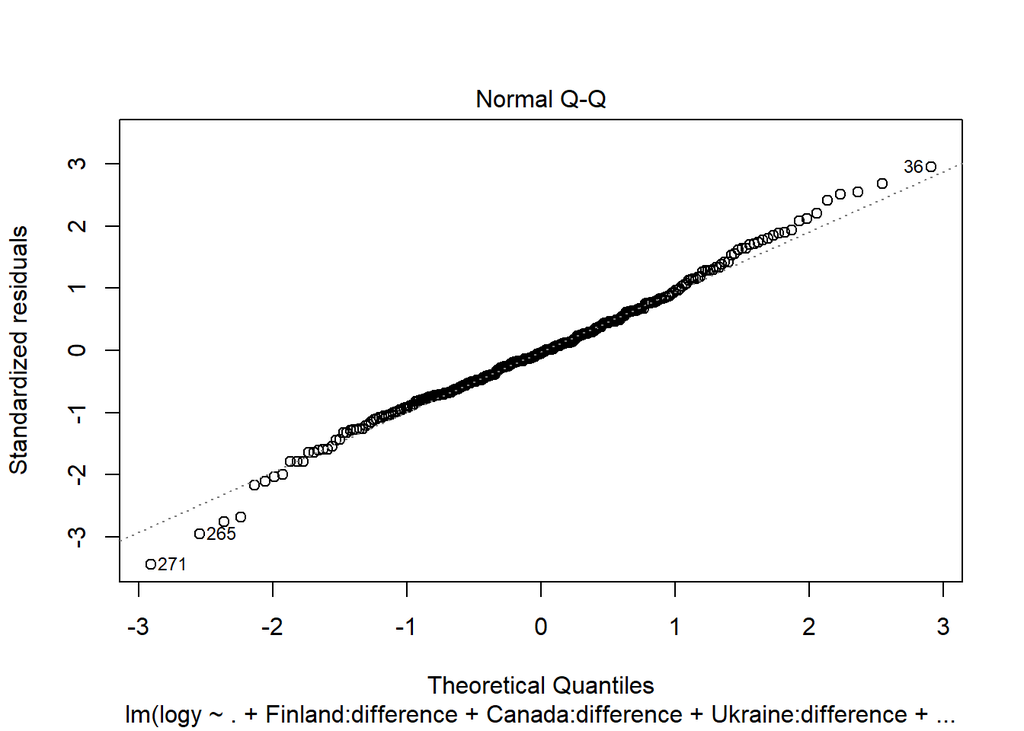

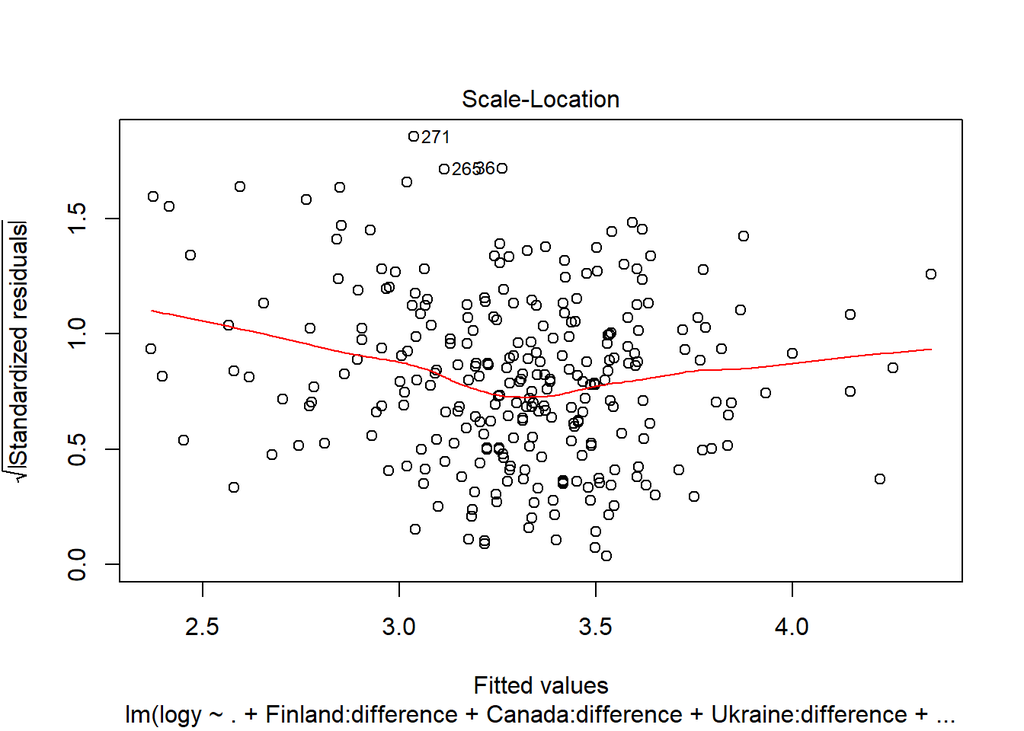

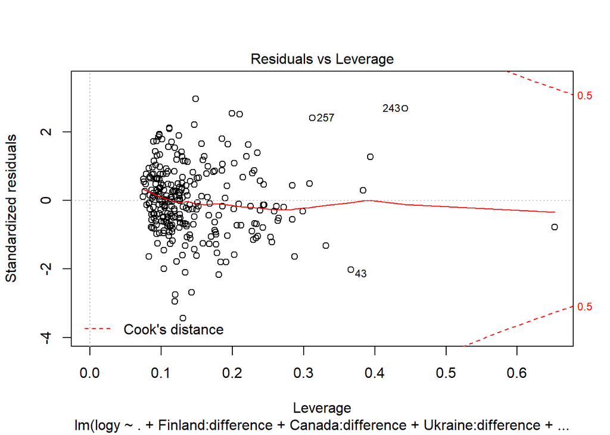

```r
plot(fit.lm.11)
```

```r
anova(fit.lm.11, fit.lm.10)
```

```
## Analysis of Variance Table
##
## Model 1: logy ~ rate_sd1 + rate_sd2 + rate_sd3 + rate_sd4 + avg_rate_q1 +
##     avg_rate_q2 + avg_rate_q3 + avg_rate_q4 + median_rate_q1 +
##     median_rate_q2 + median_rate_q3 + median_rate_q4 + sd_q1 +
##     sd_q2 + sd_q3 + sd_q4 + avg_sec_q1 + avg_sec_q2 + avg_sec_q3 +
##     avg_sec_q4 + median_sec_q1 + median_sec_q2 + median_sec_q3 +
##     median_sec_q4 + range_q1 + range_q2 + range_q3 + range_q4 +
##     difference + Australia + Belarus + Belgium + Canada + Denmark +
##     Finland + France + Germany + India + Ireland + Japan + Mexico +
##     NZ + Russia + Singapore + Spain + Sweden + Switzerland +
##     Ukraine + UK + US + Yards + MaxSeconds + MinSeconds + Finland:difference +
##     Canada:difference + Ukraine:difference + Switzerland:difference +
##     Denmark:difference + Belgium:difference + Ireland:difference +
##     UK:difference + Germany:difference + France:difference +
##     NZ:difference + US:difference + Japan:difference + Spain:difference +
##     Australia:difference + Mexico:difference + India:difference +
##     Singapore:difference + Russia:difference - difference - Yards -
##     Sweden - median_rate_q1 - median_rate_q2 - median_rate_q3 -
##     median_rate_q4 - median_sec_q2 - median_sec_q3 - median_sec_q4 -
##     Russia - Finland - Canada - Ukraine - Switzerland - Denmark -
##     Belgium - Ireland - UK - Germany - France - NZ - US - Japan -
##     Spain - Australia - Mexico - India - Singapore - Belarus -
##     rate_sd1 - rate_sd2 - rate_sd3 - rate_sd4
## Model 2: logy ~ rate_sd1 + rate_sd2 + rate_sd3 + rate_sd4 + avg_rate_q1 +
##     avg_rate_q2 + avg_rate_q3 + avg_rate_q4 + median_rate_q1 +
##     median_rate_q2 + median_rate_q3 + median_rate_q4 + sd_q1 +
##     sd_q2 + sd_q3 + sd_q4 + avg_sec_q1 + avg_sec_q2 + avg_sec_q3 +
##     avg_sec_q4 + median_sec_q1 + median_sec_q2 + median_sec_q3 +
##     median_sec_q4 + range_q1 + range_q2 + range_q3 + range_q4 +
##     difference + Australia + Belarus + Belgium + Canada + Denmark +
##     Finland + France + Germany + India + Ireland + Japan + Mexico +
##     NZ + Russia + Singapore + Spain + Sweden + Switzerland +
##     Ukraine + UK + US + Yards + MaxSeconds + MinSeconds + Finland:difference +
##     Canada:difference + Ukraine:difference + Switzerland:difference +
##     Denmark:difference + Belgium:difference + Ireland:difference +
##     UK:difference + Germany:difference + France:difference +
##     NZ:difference + US:difference + Japan:difference + Spain:difference +
##     Australia:difference + Mexico:difference + India:difference +
##     Singapore:difference + Russia:difference - difference - Yards -
##     Sweden - median_rate_q1 - median_rate_q2 - median_rate_q3 -
##     median_rate_q4 - Russia - Finland - Canada - Ukraine - Switzerland -
##     Denmark - Belgium - Ireland - UK - Germany - France - NZ -
##     US - Japan - Spain - Australia - Mexico - India - Singapore -
##     Belarus - rate_sd1 - rate_sd2 - rate_sd3 - rate_sd4
##   Res.Df    RSS Df Sum of Sq      F Pr(>F)
## 1    237 5.1281
## 2    234 5.1217  3  0.006336 0.0965 0.9619
```

Remove average rate.

```r
fit.lm.12 = lm(logy ~ .+
                Finland:difference+
                Canada:difference+
                Ukraine:difference+
                Switzerland:difference+
                Denmark:difference+
                Belgium:difference+
                Ireland:difference+
                UK:difference+
                Germany:difference+
                France:difference+
                NZ:difference+
                US:difference+
                Japan:difference+
                Spain:difference+
                Australia:difference+
                Mexico:difference+
                India:difference+
                Singapore:difference+
                Russia:difference
                - difference
                - Yards
                -Sweden
              - median_rate_q1
              - median_rate_q2
              - median_rate_q3
              - median_rate_q4
              - median_sec_q2
              - median_sec_q3
              - median_sec_q4
              - avg_rate_q1
              - avg_rate_q2
              - avg_rate_q3
                -Russia
                -Finland
                -Canada
                -Ukraine
                -Switzerland
                -Denmark
                -Belgium
                -Ireland
                -UK
                -Germany
                -France
                -NZ
                -US
                -Japan
                -Spain
                -Australia
                -Mexico
                -India
                -Singapore
                -Belarus
                - rate_sd1
                - rate_sd2
                -rate_sd3
                -rate_sd4
              ,data = df.filtered.2)
summary(fit.lm.12)
```

```
##
## Call:
## lm(formula = logy ~ . + Finland:difference + Canada:difference +
##     Ukraine:difference + Switzerland:difference + Denmark:difference +
##     Belgium:difference + Ireland:difference + UK:difference +
##     Germany:difference + France:difference + NZ:difference +
##     US:difference + Japan:difference + Spain:difference + Australia:difference +
##     Mexico:difference + India:difference + Singapore:difference +
##     Russia:difference - difference - Yards - Sweden - median_rate_q1 -
##     median_rate_q2 - median_rate_q3 - median_rate_q4 - median_sec_q2 -
##     median_sec_q3 - median_sec_q4 - avg_rate_q1 - avg_rate_q2 -
##     avg_rate_q3 - Russia - Finland - Canada - Ukraine - Switzerland -
##     Denmark - Belgium - Ireland - UK - Germany - France - NZ -
##     US - Japan - Spain - Australia - Mexico - India - Singapore -
##     Belarus - rate_sd1 - rate_sd2 - rate_sd3 - rate_sd4, data = df.filtered.2)
##
## Residuals:
##      Min       1Q   Median       3Q      Max
## -0.46023 -0.08929 -0.00540  0.07741  0.41232
##
## Coefficients:
##                           Estimate Std. Error t value Pr(>|t|)
## (Intercept)              2.988e+00  3.120e-01   9.578  < 2e-16 ***
## avg_rate_q4             -1.946e-03  3.396e-04  -5.730 2.99e-08 ***
## sd_q1                   -6.273e-03  6.464e-04  -9.704  < 2e-16 ***
## sd_q2                   -9.189e-04  5.641e-04  -1.629  0.10462
## sd_q3                   -4.077e-03  6.068e-04  -6.719 1.32e-10 ***
## sd_q4                   -2.504e-03  4.096e-04  -6.113 3.93e-09 ***
## avg_sec_q1              -9.773e-04  3.920e-04  -2.493  0.01333 *
## avg_sec_q2               8.412e-05  1.545e-04   0.544  0.58673
## avg_sec_q3              -6.130e-04  1.524e-04  -4.023 7.70e-05 ***
## avg_sec_q4               1.356e-04  1.425e-04   0.952  0.34217
## median_sec_q1            9.790e-04  3.598e-04   2.721  0.00698 **
## range_q1                 2.459e-03  2.244e-04  10.960  < 2e-16 ***
## range_q2                 3.967e-04  1.897e-04   2.090  0.03763 *
## range_q3                 1.512e-03  2.182e-04   6.931 3.82e-11 ***
## range_q4                 1.011e-03  1.615e-04   6.260 1.75e-09 ***
## MaxSeconds               3.010e-05  1.481e-04   0.203  0.83917
## MinSeconds               3.312e-04  1.031e-04   3.212  0.00150 **
## difference:Finland0      2.732e-02  2.038e-02   1.341  0.18134
```

[output cut: 10 more lines]

```
## difference:NZ1          -1.324e-02  9.183e-03  -1.442  0.15069
## difference:US1          -1.193e-02  1.211e-02  -0.985  0.32568
## difference:Japan1       -3.876e-03  5.218e-03  -0.743  0.45829
## difference:Spain1       -1.481e-02  1.249e-02  -1.186  0.23680
## difference:Australia1   -1.309e-02  8.824e-03  -1.483  0.13938
## difference:Mexico1      -1.997e-02  1.316e-02  -1.517  0.13048
## difference:India1       -8.015e-03  8.383e-03  -0.956  0.33995
## difference:Singapore1   -8.211e-03  5.108e-03  -1.607  0.10926
## difference:Russia1      -9.291e-04  4.418e-03  -0.210  0.83360
## ---
## Signif. codes:  0 '***' 0.001 '**' 0.01 '*' 0.05 '.' 0.1 ' ' 1
##
## Residual standard error: 0.1475 on 240 degrees of freedom
## Multiple R-squared:  0.8479, Adjusted R-squared:  0.8251
## F-statistic: 37.16 on 36 and 240 DF,  p-value: < 2.2e-16
```

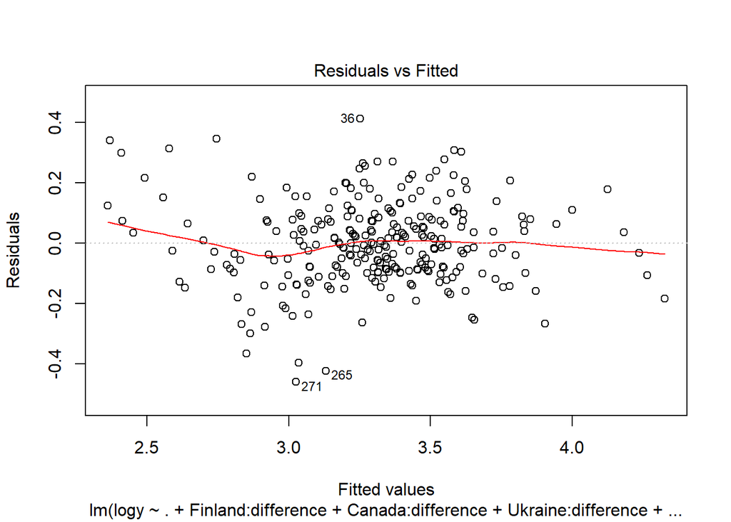

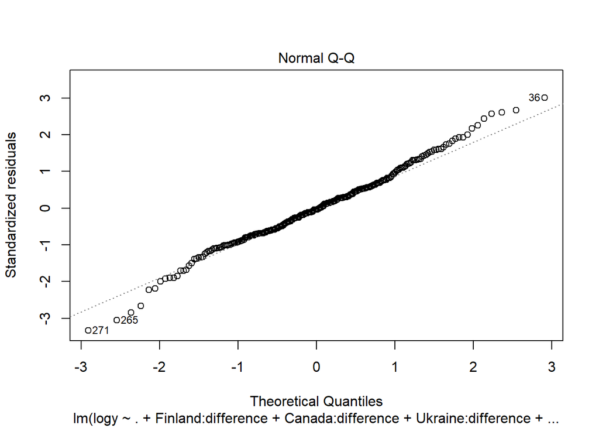

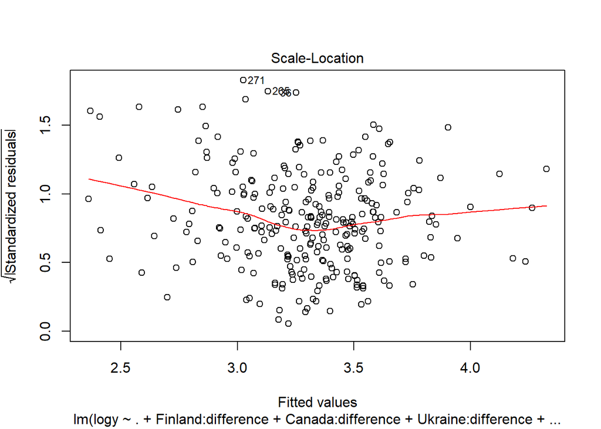

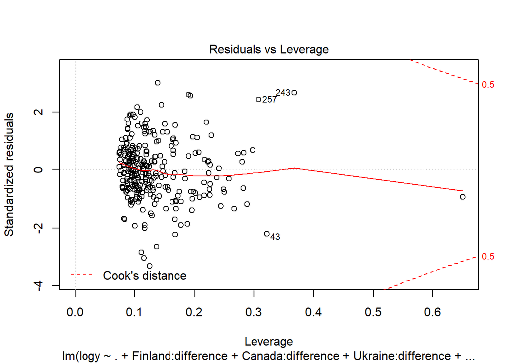

```r
plot(fit.lm.12)
```

```r
anova(fit.lm.11, fit.lm.12)
```

```
## Analysis of Variance Table
##
## Model 1: logy ~ rate_sd1 + rate_sd2 + rate_sd3 + rate_sd4 + avg_rate_q1 +
##     avg_rate_q2 + avg_rate_q3 + avg_rate_q4 + median_rate_q1 +
##     median_rate_q2 + median_rate_q3 + median_rate_q4 + sd_q1 +
##     sd_q2 + sd_q3 + sd_q4 + avg_sec_q1 + avg_sec_q2 + avg_sec_q3 +
##     avg_sec_q4 + median_sec_q1 + median_sec_q2 + median_sec_q3 +
##     median_sec_q4 + range_q1 + range_q2 + range_q3 + range_q4 +
##     difference + Australia + Belarus + Belgium + Canada + Denmark +
##     Finland + France + Germany + India + Ireland + Japan + Mexico +
##     NZ + Russia + Singapore + Spain + Sweden + Switzerland +
##     Ukraine + UK + US + Yards + MaxSeconds + MinSeconds + Finland:difference +
##     Canada:difference + Ukraine:difference + Switzerland:difference +
##     Denmark:difference + Belgium:difference + Ireland:difference +
##     UK:difference + Germany:difference + France:difference +
##     NZ:difference + US:difference + Japan:difference + Spain:difference +
##     Australia:difference + Mexico:difference + India:difference +
##     Singapore:difference + Russia:difference - difference - Yards -
##     Sweden - median_rate_q1 - median_rate_q2 - median_rate_q3 -
##     median_rate_q4 - median_sec_q2 - median_sec_q3 - median_sec_q4 -
##     Russia - Finland - Canada - Ukraine - Switzerland - Denmark -
##     Belgium - Ireland - UK - Germany - France - NZ - US - Japan -
##     Spain - Australia - Mexico - India - Singapore - Belarus -
##     rate_sd1 - rate_sd2 - rate_sd3 - rate_sd4
## Model 2: logy ~ rate_sd1 + rate_sd2 + rate_sd3 + rate_sd4 + avg_rate_q1 +
##     avg_rate_q2 + avg_rate_q3 + avg_rate_q4 + median_rate_q1 +
##     median_rate_q2 + median_rate_q3 + median_rate_q4 + sd_q1 +
##     sd_q2 + sd_q3 + sd_q4 + avg_sec_q1 + avg_sec_q2 + avg_sec_q3 +
##     avg_sec_q4 + median_sec_q1 + median_sec_q2 + median_sec_q3 +
##     median_sec_q4 + range_q1 + range_q2 + range_q3 + range_q4 +
##     difference + Australia + Belarus + Belgium + Canada + Denmark +
##     Finland + France + Germany + India + Ireland + Japan + Mexico +
##     NZ + Russia + Singapore + Spain + Sweden + Switzerland +
##     Ukraine + UK + US + Yards + MaxSeconds + MinSeconds + Finland:difference +
##     Canada:difference + Ukraine:difference + Switzerland:difference +
##     Denmark:difference + Belgium:difference + Ireland:difference +
##     UK:difference + Germany:difference + France:difference +
##     NZ:difference + US:difference + Japan:difference + Spain:difference +
##     Australia:difference + Mexico:difference + India:difference +
##     Singapore:difference + Russia:difference - difference - Yards -
##     Sweden - median_rate_q1 - median_rate_q2 - median_rate_q3 -
##     median_rate_q4 - median_sec_q2 - median_sec_q3 - median_sec_q4 -
##     avg_rate_q1 - avg_rate_q2 - avg_rate_q3 - Russia - Finland -
##     Canada - Ukraine - Switzerland - Denmark - Belgium - Ireland -
##     UK - Germany - France - NZ - US - Japan - Spain - Australia -
##     Mexico - India - Singapore - Belarus - rate_sd1 - rate_sd2 -
##     rate_sd3 - rate_sd4
##   Res.Df    RSS Df Sum of Sq     F Pr(>F)
## 1    237 5.1281
## 2    240 5.2199 -3 -0.091787 1.414 0.2393
```

Remove Max Seconds

```r
fit.lm.13 = lm(logy ~ .+
                Finland:difference+
                Canada:difference+
                Ukraine:difference+
                Switzerland:difference+
                Denmark:difference+
                Belgium:difference+
                Ireland:difference+
                UK:difference+
                Germany:difference+
                France:difference+
                NZ:difference+
                US:difference+
                Japan:difference+
                Spain:difference+
                Australia:difference+
                Mexico:difference+
                India:difference+
                Singapore:difference+
                Russia:difference
                - difference
                - Yards
                -Sweden
              - median_rate_q1
              - median_rate_q2
              - median_rate_q3
              - median_rate_q4
              - median_sec_q2
              - median_sec_q3
              - median_sec_q4
              - avg_rate_q1
              - avg_rate_q2
              - avg_rate_q3
                -Russia
              - MaxSeconds
                -Finland
                -Canada
                -Ukraine
                -Switzerland
                -Denmark
                -Belgium
                -Ireland
                -UK
                -Germany
                -France
                -NZ
                -US
                -Japan
                -Spain
                -Australia
                -Mexico
                -India
                -Singapore
                -Belarus
                - rate_sd1
                - rate_sd2
                -rate_sd3
                -rate_sd4
              ,data = df.filtered.2)
summary(fit.lm.13)
```

```
##
## Call:
## lm(formula = logy ~ . + Finland:difference + Canada:difference +
##     Ukraine:difference + Switzerland:difference + Denmark:difference +
##     Belgium:difference + Ireland:difference + UK:difference +
##     Germany:difference + France:difference + NZ:difference +
##     US:difference + Japan:difference + Spain:difference + Australia:difference +
##     Mexico:difference + India:difference + Singapore:difference +
##     Russia:difference - difference - Yards - Sweden - median_rate_q1 -
##     median_rate_q2 - median_rate_q3 - median_rate_q4 - median_sec_q2 -
##     median_sec_q3 - median_sec_q4 - avg_rate_q1 - avg_rate_q2 -
##     avg_rate_q3 - Russia - MaxSeconds - Finland - Canada - Ukraine -
##     Switzerland - Denmark - Belgium - Ireland - UK - Germany -
##     France - NZ - US - Japan - Spain - Australia - Mexico - India -
##     Singapore - Belarus - rate_sd1 - rate_sd2 - rate_sd3 - rate_sd4,
##     data = df.filtered.2)
##
## Residuals:
##      Min       1Q   Median       3Q      Max
## -0.46239 -0.09052 -0.00480  0.07685  0.41622
##
## Coefficients:
##                           Estimate Std. Error t value Pr(>|t|)
## (Intercept)              2.997e+00  3.082e-01   9.725  < 2e-16 ***
## avg_rate_q4             -1.918e-03  3.107e-04  -6.174 2.80e-09 ***
## sd_q1                   -6.290e-03  6.398e-04  -9.831  < 2e-16 ***
## sd_q2                   -9.080e-04  5.604e-04  -1.620 0.106489
## sd_q3                   -4.061e-03  6.001e-04  -6.766 9.95e-11 ***
## sd_q4                   -2.515e-03  4.052e-04  -6.206 2.35e-09 ***
## avg_sec_q1              -9.765e-04  3.912e-04  -2.496 0.013221 *
## avg_sec_q2               8.307e-05  1.542e-04   0.539 0.590483
## avg_sec_q3              -6.109e-04  1.517e-04  -4.026 7.59e-05 ***
## avg_sec_q4               1.546e-04  1.073e-04   1.441 0.151000
## median_sec_q1            9.789e-04  3.591e-04   2.726 0.006878 **
## range_q1                 2.467e-03  2.203e-04  11.200  < 2e-16 ***
## range_q2                 3.947e-04  1.891e-04   2.087 0.037931 *
## range_q3                 1.510e-03  2.175e-04   6.944 3.52e-11 ***
## range_q4                 1.027e-03  1.422e-04   7.221 6.71e-12 ***
## MinSeconds               3.365e-04  9.958e-05   3.380 0.000847 ***
## difference:Finland0      2.773e-02  2.024e-02   1.370 0.171878
```

[output cut: 10 more lines]

```
## difference:NZ1          -1.339e-02  9.134e-03  -1.467 0.143806
## difference:US1          -1.216e-02  1.204e-02  -1.010 0.313601
## difference:Japan1       -3.952e-03  5.194e-03  -0.761 0.447514
## difference:Spain1       -1.506e-02  1.240e-02  -1.214 0.225896
## difference:Australia1   -1.325e-02  8.770e-03  -1.511 0.132181
## difference:Mexico1      -2.025e-02  1.306e-02  -1.550 0.122342
## difference:India1       -8.185e-03  8.324e-03  -0.983 0.326442
## difference:Singapore1   -8.293e-03  5.082e-03  -1.632 0.104011
## difference:Russia1      -8.913e-04  4.405e-03  -0.202 0.839819
## ---
## Signif. codes:  0 '***' 0.001 '**' 0.01 '*' 0.05 '.' 0.1 ' ' 1
##
## Residual standard error: 0.1472 on 241 degrees of freedom
## Multiple R-squared:  0.8479, Adjusted R-squared:  0.8258
## F-statistic: 38.37 on 35 and 241 DF,  p-value: < 2.2e-16
```

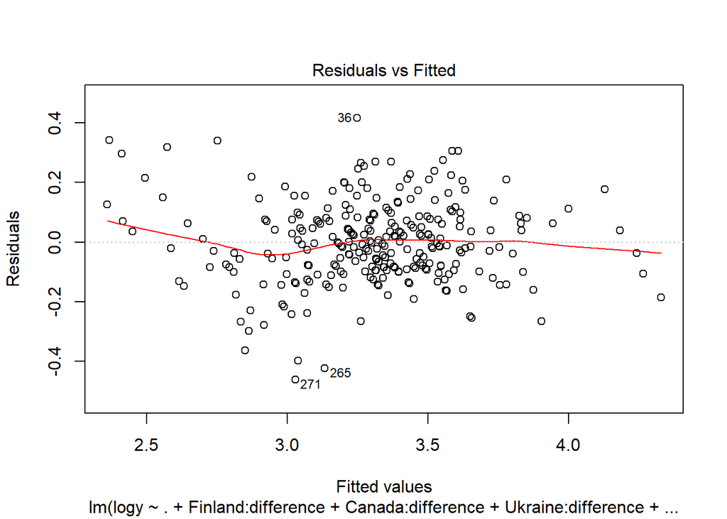

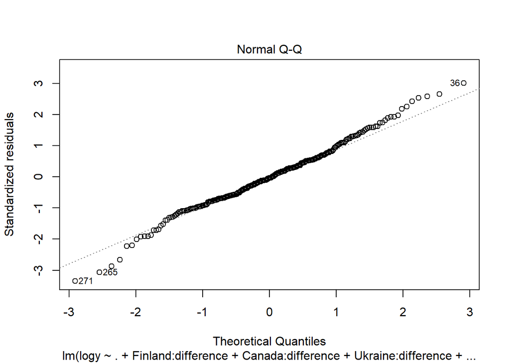

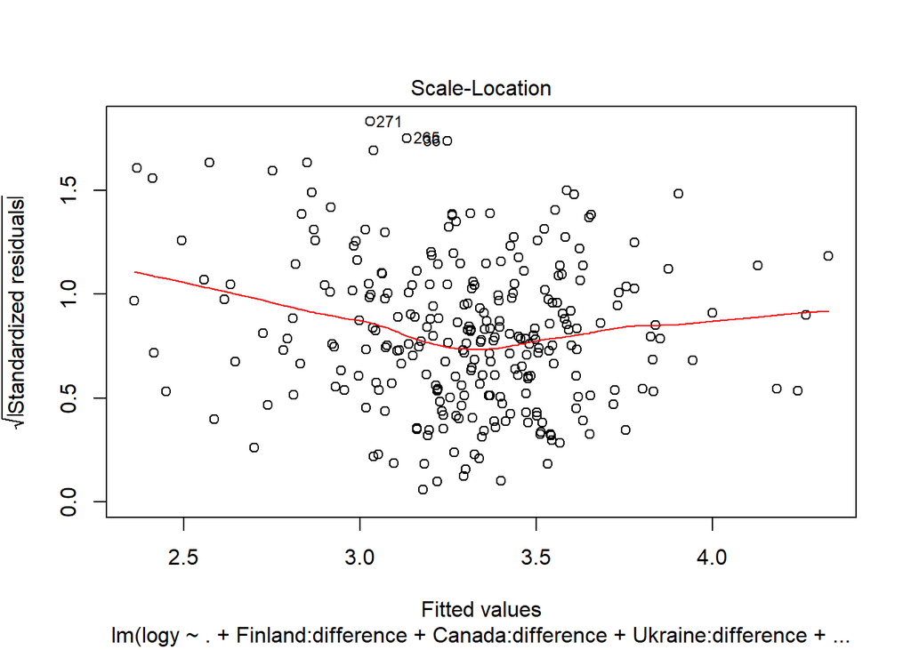

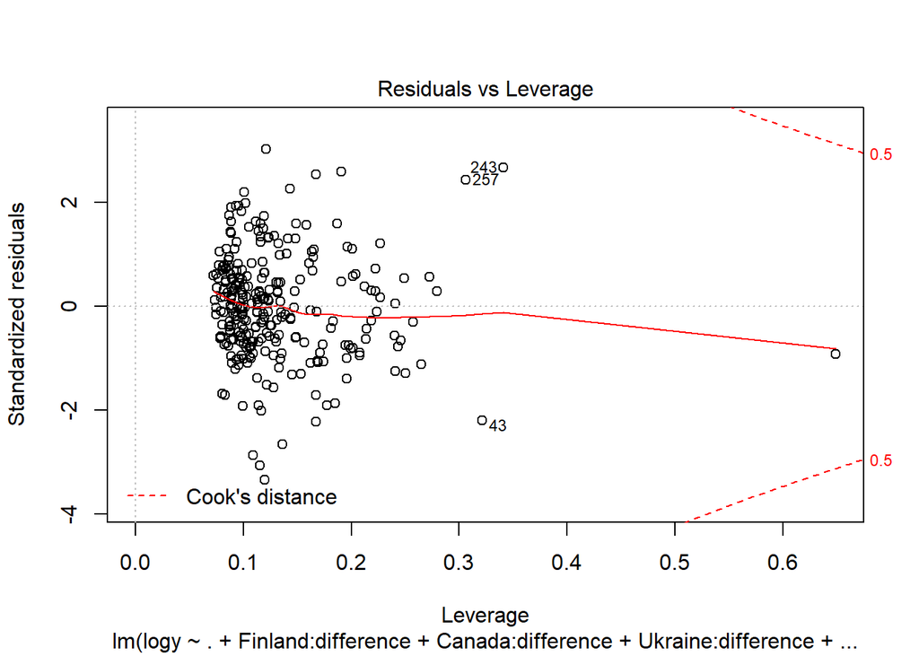

```r
plot(fit.lm.13)
```

```r
anova(fit.lm.13, fit.lm.12)
```

```
## Analysis of Variance Table
##
## Model 1: logy ~ rate_sd1 + rate_sd2 + rate_sd3 + rate_sd4 + avg_rate_q1 +
##     avg_rate_q2 + avg_rate_q3 + avg_rate_q4 + median_rate_q1 +
##     median_rate_q2 + median_rate_q3 + median_rate_q4 + sd_q1 +
##     sd_q2 + sd_q3 + sd_q4 + avg_sec_q1 + avg_sec_q2 + avg_sec_q3 +
##     avg_sec_q4 + median_sec_q1 + median_sec_q2 + median_sec_q3 +
##     median_sec_q4 + range_q1 + range_q2 + range_q3 + range_q4 +
##     difference + Australia + Belarus + Belgium + Canada + Denmark +
##     Finland + France + Germany + India + Ireland + Japan + Mexico +
##     NZ + Russia + Singapore + Spain + Sweden + Switzerland +
##     Ukraine + UK + US + Yards + MaxSeconds + MinSeconds + Finland:difference +
##     Canada:difference + Ukraine:difference + Switzerland:difference +
##     Denmark:difference + Belgium:difference + Ireland:difference +
##     UK:difference + Germany:difference + France:difference +
##     NZ:difference + US:difference + Japan:difference + Spain:difference +
##     Australia:difference + Mexico:difference + India:difference +
##     Singapore:difference + Russia:difference - difference - Yards -
##     Sweden - median_rate_q1 - median_rate_q2 - median_rate_q3 -
##     median_rate_q4 - median_sec_q2 - median_sec_q3 - median_sec_q4 -
##     avg_rate_q1 - avg_rate_q2 - avg_rate_q3 - Russia - MaxSeconds -
##     Finland - Canada - Ukraine - Switzerland - Denmark - Belgium -
##     Ireland - UK - Germany - France - NZ - US - Japan - Spain -
##     Australia - Mexico - India - Singapore - Belarus - rate_sd1 -
##     rate_sd2 - rate_sd3 - rate_sd4
## Model 2: logy ~ rate_sd1 + rate_sd2 + rate_sd3 + rate_sd4 + avg_rate_q1 +
##     avg_rate_q2 + avg_rate_q3 + avg_rate_q4 + median_rate_q1 +
##     median_rate_q2 + median_rate_q3 + median_rate_q4 + sd_q1 +
##     sd_q2 + sd_q3 + sd_q4 + avg_sec_q1 + avg_sec_q2 + avg_sec_q3 +
##     avg_sec_q4 + median_sec_q1 + median_sec_q2 + median_sec_q3 +
##     median_sec_q4 + range_q1 + range_q2 + range_q3 + range_q4 +
##     difference + Australia + Belarus + Belgium + Canada + Denmark +
##     Finland + France + Germany + India + Ireland + Japan + Mexico +
##     NZ + Russia + Singapore + Spain + Sweden + Switzerland +
##     Ukraine + UK + US + Yards + MaxSeconds + MinSeconds + Finland:difference +
##     Canada:difference + Ukraine:difference + Switzerland:difference +
##     Denmark:difference + Belgium:difference + Ireland:difference +
##     UK:difference + Germany:difference + France:difference +
##     NZ:difference + US:difference + Japan:difference + Spain:difference +
##     Australia:difference + Mexico:difference + India:difference +
##     Singapore:difference + Russia:difference - difference - Yards -
##     Sweden - median_rate_q1 - median_rate_q2 - median_rate_q3 -
##     median_rate_q4 - median_sec_q2 - median_sec_q3 - median_sec_q4 -
##     avg_rate_q1 - avg_rate_q2 - avg_rate_q3 - Russia - Finland -
##     Canada - Ukraine - Switzerland - Denmark - Belgium - Ireland -
##     UK - Germany - France - NZ - US - Japan - Spain - Australia -
##     Mexico - India - Singapore - Belarus - rate_sd1 - rate_sd2 -
##     rate_sd3 - rate_sd4
##   Res.Df    RSS Df  Sum of Sq      F Pr(>F)
## 1    241 5.2208
## 2    240 5.2199  1 0.00089778 0.0413 0.8392
```

```r
fit.lm.14 = lm(logy ~ .+
                Finland:difference+
                Canada:difference+
                Ukraine:difference+
                Switzerland:difference+
                Denmark:difference+
                Belgium:difference+
                Ireland:difference+
                UK:difference+
                Germany:difference+
                France:difference+
                NZ:difference+
                US:difference+
                Japan:difference+
                Spain:difference+
                Australia:difference+
                Mexico:difference+
                India:difference+
                Singapore:difference+
                Russia:difference
                - difference
                - Yards
                -Sweden
              - median_rate_q1
              - median_rate_q2
              - median_rate_q3
              - median_rate_q4
              - median_sec_q2
              - median_sec_q3
              - median_sec_q4
              - avg_rate_q1
              - avg_rate_q2
              - avg_rate_q3
                -Russia
              - MaxSeconds
                -Finland
                -Canada
                -Ukraine
                -Switzerland
                -Denmark
                -Belgium
                -Ireland
                -UK
                -Germany
                -France
                -NZ
                -US
                -Japan
                -Spain
                -Australia
                -Mexico
                -India
                -Singapore
                -Belarus
                - rate_sd1
                - rate_sd2
                -rate_sd3
                -rate_sd4
                -avg_sec_q2
                -sd_q2
                - avg_sec_q4
              ,data = df.filtered.2)
summary(fit.lm.14)
```

```
##
## Call:
## lm(formula = logy ~ . + Finland:difference + Canada:difference +
##     Ukraine:difference + Switzerland:difference + Denmark:difference +
##     Belgium:difference + Ireland:difference + UK:difference +
##     Germany:difference + France:difference + NZ:difference +
##     US:difference + Japan:difference + Spain:difference + Australia:difference +
##     Mexico:difference + India:difference + Singapore:difference +
##     Russia:difference - difference - Yards - Sweden - median_rate_q1 -
##     median_rate_q2 - median_rate_q3 - median_rate_q4 - median_sec_q2 -
##     median_sec_q3 - median_sec_q4 - avg_rate_q1 - avg_rate_q2 -
##     avg_rate_q3 - Russia - MaxSeconds - Finland - Canada - Ukraine -
##     Switzerland - Denmark - Belgium - Ireland - UK - Germany -
##     France - NZ - US - Japan - Spain - Australia - Mexico - India -
##     Singapore - Belarus - rate_sd1 - rate_sd2 - rate_sd3 - rate_sd4 -
##     avg_sec_q2 - sd_q2 - avg_sec_q4, data = df.filtered.2)
##
## Residuals:
##      Min       1Q   Median       3Q      Max
## -0.45701 -0.09074 -0.00049  0.09121  0.43046
##
## Coefficients:
##                           Estimate Std. Error t value Pr(>|t|)
## (Intercept)              3.010e+00  3.079e-01   9.777  < 2e-16 ***
## avg_rate_q4             -1.655e-03  2.593e-04  -6.381 8.76e-10 ***
## sd_q1                   -6.476e-03  6.188e-04 -10.466  < 2e-16 ***
## sd_q3                   -4.354e-03  5.825e-04  -7.475 1.38e-12 ***
## sd_q4                   -2.637e-03  4.008e-04  -6.578 2.89e-10 ***
## avg_sec_q1              -9.606e-04  3.822e-04  -2.513 0.012602 *
## avg_sec_q3              -4.388e-04  9.179e-05  -4.780 3.03e-06 ***
## median_sec_q1            1.028e-03  3.579e-04   2.873 0.004420 **
## range_q1                 2.539e-03  2.108e-04  12.043  < 2e-16 ***
## range_q2                 1.019e-04  6.121e-05   1.664 0.097348 .
## range_q3                 1.618e-03  2.091e-04   7.738 2.66e-13 ***
## range_q4                 1.052e-03  1.407e-04   7.480 1.34e-12 ***
## MinSeconds               3.341e-04  9.974e-05   3.350 0.000937 ***
## difference:Finland0      2.779e-02  2.029e-02   1.370 0.171960
## difference:Finland1      2.186e-02  1.162e-02   1.881 0.061172 .
## difference:Canada1       7.787e-03  4.485e-03   1.736 0.083777 .
## difference:Ukraine1      7.053e-03  5.932e-03   1.189 0.235655
## difference:Switzerland1  7.085e-03  1.444e-02   0.491 0.624199
## difference:Denmark1     -1.011e-02  8.715e-03  -1.160 0.247131
## difference:Belgium1      1.164e-02  4.411e-03   2.639 0.008848 **
## difference:Ireland1     -1.921e-03  5.679e-03  -0.338 0.735423
## difference:UK1          -3.910e-03  5.604e-03  -0.698 0.486032
## difference:Germany1     -3.549e-03  6.561e-03  -0.541 0.589044
## difference:France1      -2.954e-03  5.065e-03  -0.583 0.560257
## difference:NZ1          -1.373e-02  9.162e-03  -1.498 0.135374
## difference:US1          -1.247e-02  1.207e-02  -1.033 0.302492
## difference:Japan1       -3.962e-03  5.201e-03  -0.762 0.446897
## difference:Spain1       -1.473e-02  1.243e-02  -1.185 0.236981
## difference:Australia1   -1.343e-02  8.788e-03  -1.529 0.127631
## difference:Mexico1      -2.041e-02  1.309e-02  -1.560 0.120082
## difference:India1       -8.657e-03  8.307e-03  -1.042 0.298392
## difference:Singapore1   -8.592e-03  5.065e-03  -1.697 0.091063 .
## difference:Russia1      -1.580e-03  4.369e-03  -0.362 0.717827
## ---
## Signif. codes:  0 '***' 0.001 '**' 0.01 '*' 0.05 '.' 0.1 ' ' 1
##
## Residual standard error: 0.1477 on 244 degrees of freedom
## Multiple R-squared:  0.8448, Adjusted R-squared:  0.8245
## F-statistic: 41.52 on 32 and 244 DF,  p-value: < 2.2e-16
```

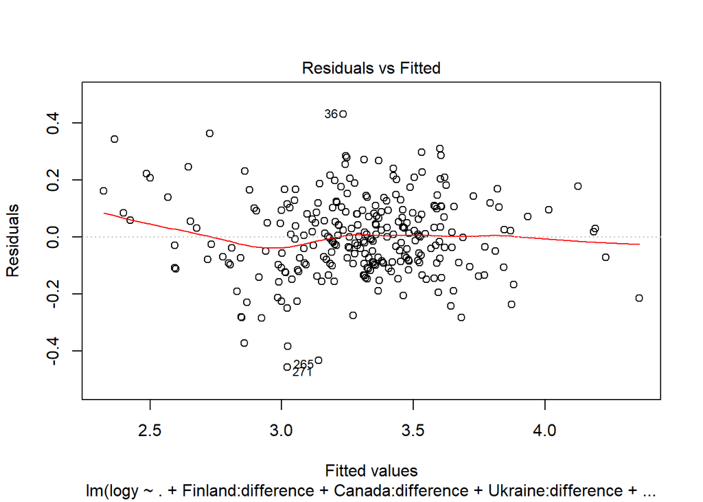

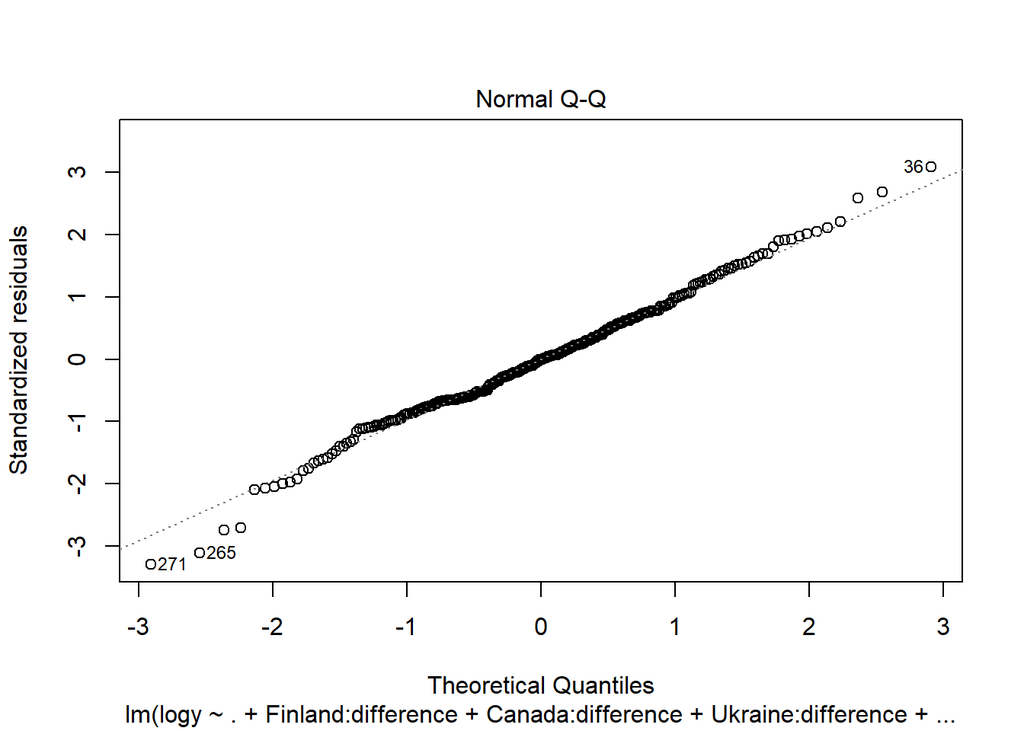

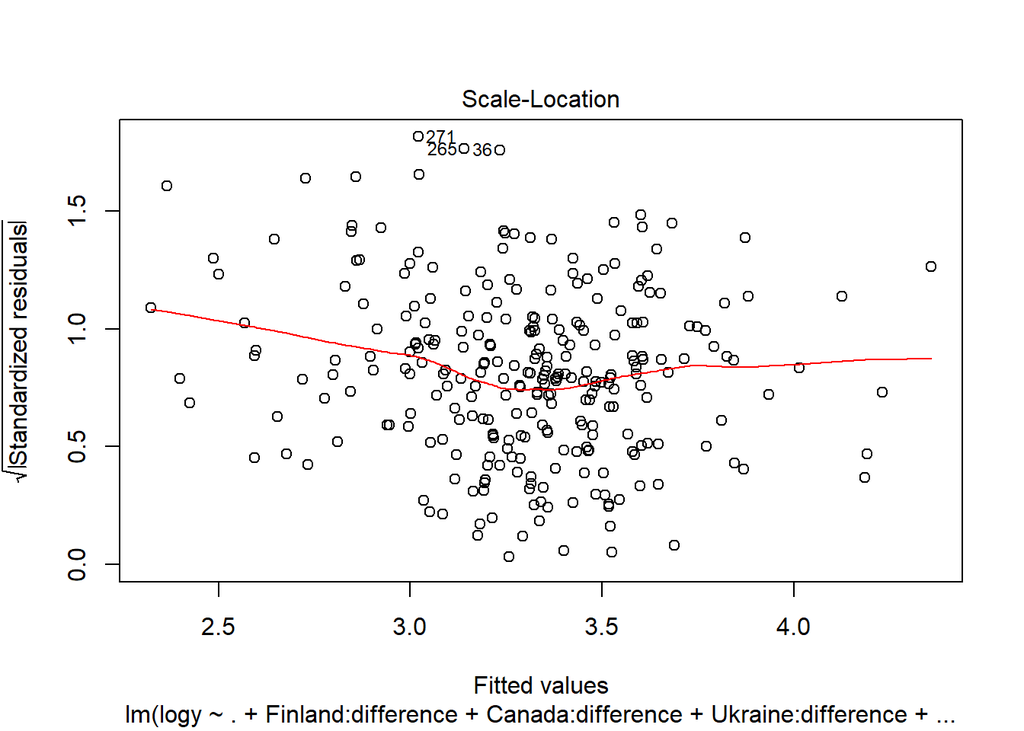

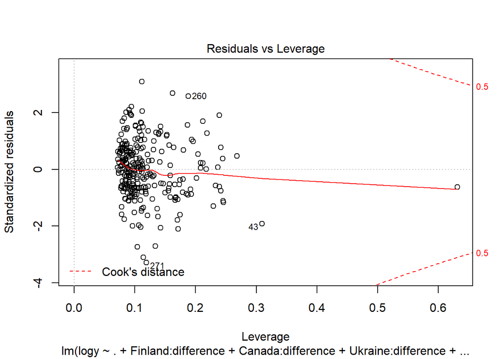

```r
plot(fit.lm.14)
```

```r
anova(fit.lm.14, fit.lm.13)
```

```
## Analysis of Variance Table
##
## Model 1: logy ~ rate_sd1 + rate_sd2 + rate_sd3 + rate_sd4 + avg_rate_q1 +
##     avg_rate_q2 + avg_rate_q3 + avg_rate_q4 + median_rate_q1 +
##     median_rate_q2 + median_rate_q3 + median_rate_q4 + sd_q1 +
##     sd_q2 + sd_q3 + sd_q4 + avg_sec_q1 + avg_sec_q2 + avg_sec_q3 +
##     avg_sec_q4 + median_sec_q1 + median_sec_q2 + median_sec_q3 +
##     median_sec_q4 + range_q1 + range_q2 + range_q3 + range_q4 +
##     difference + Australia + Belarus + Belgium + Canada + Denmark +
##     Finland + France + Germany + India + Ireland + Japan + Mexico +
##     NZ + Russia + Singapore + Spain + Sweden + Switzerland +
##     Ukraine + UK + US + Yards + MaxSeconds + MinSeconds + Finland:difference +
##     Canada:difference + Ukraine:difference + Switzerland:difference +
##     Denmark:difference + Belgium:difference + Ireland:difference +
##     UK:difference + Germany:difference + France:difference +
##     NZ:difference + US:difference + Japan:difference + Spain:difference +
##     Australia:difference + Mexico:difference + India:difference +
##     Singapore:difference + Russia:difference - difference - Yards -
##     Sweden - median_rate_q1 - median_rate_q2 - median_rate_q3 -
##     median_rate_q4 - median_sec_q2 - median_sec_q3 - median_sec_q4 -
##     avg_rate_q1 - avg_rate_q2 - avg_rate_q3 - Russia - MaxSeconds -
##     Finland - Canada - Ukraine - Switzerland - Denmark - Belgium -
##     Ireland - UK - Germany - France - NZ - US - Japan - Spain -
##     Australia - Mexico - India - Singapore - Belarus - rate_sd1 -
##     rate_sd2 - rate_sd3 - rate_sd4 - avg_sec_q2 - sd_q2 - avg_sec_q4
## Model 2: logy ~ rate_sd1 + rate_sd2 + rate_sd3 + rate_sd4 + avg_rate_q1 +
##     avg_rate_q2 + avg_rate_q3 + avg_rate_q4 + median_rate_q1 +
##     median_rate_q2 + median_rate_q3 + median_rate_q4 + sd_q1 +
##     sd_q2 + sd_q3 + sd_q4 + avg_sec_q1 + avg_sec_q2 + avg_sec_q3 +
##     avg_sec_q4 + median_sec_q1 + median_sec_q2 + median_sec_q3 +
##     median_sec_q4 + range_q1 + range_q2 + range_q3 + range_q4 +
##     difference + Australia + Belarus + Belgium + Canada + Denmark +
##     Finland + France + Germany + India + Ireland + Japan + Mexico +
##     NZ + Russia + Singapore + Spain + Sweden + Switzerland +
##     Ukraine + UK + US + Yards + MaxSeconds + MinSeconds + Finland:difference +
##     Canada:difference + Ukraine:difference + Switzerland:difference +
##     Denmark:difference + Belgium:difference + Ireland:difference +
##     UK:difference + Germany:difference + France:difference +
##     NZ:difference + US:difference + Japan:difference + Spain:difference +
##     Australia:difference + Mexico:difference + India:difference +
##     Singapore:difference + Russia:difference - difference - Yards -
##     Sweden - median_rate_q1 - median_rate_q2 - median_rate_q3 -
##     median_rate_q4 - median_sec_q2 - median_sec_q3 - median_sec_q4 -
##     avg_rate_q1 - avg_rate_q2 - avg_rate_q3 - Russia - MaxSeconds -
##     Finland - Canada - Ukraine - Switzerland - Denmark - Belgium -
##     Ireland - UK - Germany - France - NZ - US - Japan - Spain -
##     Australia - Mexico - India - Singapore - Belarus - rate_sd1 -
##     rate_sd2 - rate_sd3 - rate_sd4
##   Res.Df    RSS Df Sum of Sq      F Pr(>F)
## 1    244 5.3248
## 2    241 5.2208  3   0.10409 1.6017 0.1896
```

Remove interaction effects because of high multicollinearity and small sample sets. There are less than 10 runners per team, and there are guidelines which forces individual team runners to end as a team. By including them we’re overfitting.

```r
fit.lm.15 = lm(logy ~ .
                - Yards
                -Sweden
              - median_rate_q1
              - median_rate_q2
              - median_rate_q3
              - median_rate_q4
              - median_sec_q1
             - median_sec_q2
              - median_sec_q3
              - median_sec_q4
              - avg_rate_q1
              - avg_rate_q2
              - avg_rate_q3
                -Russia
              - MaxSeconds
              - difference
                -Finland
                -Canada
                -Ukraine
                -Switzerland
                -Denmark
                -Belgium
                -Ireland
                -UK
                -Germany
                -France
                -NZ
                -US
                -Japan
                -Spain
                -Australia
                -Mexico
                -India
                -Singapore
                -Belarus
                - rate_sd1
                - rate_sd2
                -rate_sd3
                -rate_sd4
                -avg_sec_q2
               -avg_sec_q1
                -sd_q2
                - avg_sec_q4
              - range_q2
              ,data = df.filtered.2)
summary(fit.lm.15)
```

```
##
## Call:
## lm(formula = logy ~ . - Yards - Sweden - median_rate_q1 - median_rate_q2 -
##     median_rate_q3 - median_rate_q4 - median_sec_q1 - median_sec_q2 -
##     median_sec_q3 - median_sec_q4 - avg_rate_q1 - avg_rate_q2 -
##     avg_rate_q3 - Russia - MaxSeconds - difference - Finland -
##     Canada - Ukraine - Switzerland - Denmark - Belgium - Ireland -
##     UK - Germany - France - NZ - US - Japan - Spain - Australia -
##     Mexico - India - Singapore - Belarus - rate_sd1 - rate_sd2 -
##     rate_sd3 - rate_sd4 - avg_sec_q2 - avg_sec_q1 - sd_q2 - avg_sec_q4 -
##     range_q2, data = df.filtered.2)
##
## Residuals:
##      Min       1Q   Median       3Q      Max
## -0.44091 -0.11308 -0.00328  0.11933  0.45103
##
## Coefficients:
##               Estimate Std. Error t value Pr(>|t|)
## (Intercept)  3.391e+00  2.021e-01  16.782  < 2e-16 ***
## avg_rate_q4 -1.535e-03  2.712e-04  -5.659 3.91e-08 ***
## sd_q1       -6.134e-03  6.351e-04  -9.658  < 2e-16 ***
## sd_q3       -4.616e-03  6.182e-04  -7.468 1.16e-12 ***
## sd_q4       -3.394e-03  4.220e-04  -8.042 2.88e-14 ***
## avg_sec_q3  -3.268e-04  8.537e-05  -3.828 0.000161 ***
## range_q1     2.445e-03  2.205e-04  11.090  < 2e-16 ***
## range_q3     1.765e-03  2.195e-04   8.039 2.95e-14 ***
## range_q4     1.323e-03  1.489e-04   8.885  < 2e-16 ***
## MinSeconds   2.938e-04  7.721e-05   3.804 0.000176 ***
## ---
## Signif. codes:  0 '***' 0.001 '**' 0.01 '*' 0.05 '.' 0.1 ' ' 1
##
## Residual standard error: 0.1678 on 267 degrees of freedom
## Multiple R-squared:  0.781,  Adjusted R-squared:  0.7737
## F-statistic: 105.8 on 9 and 267 DF,  p-value: < 2.2e-16
```

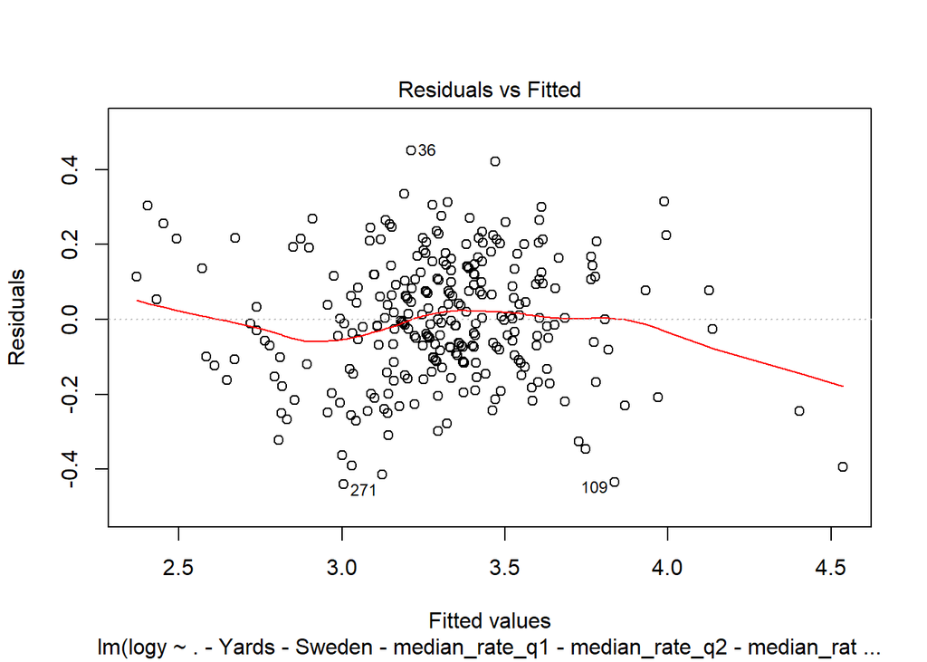

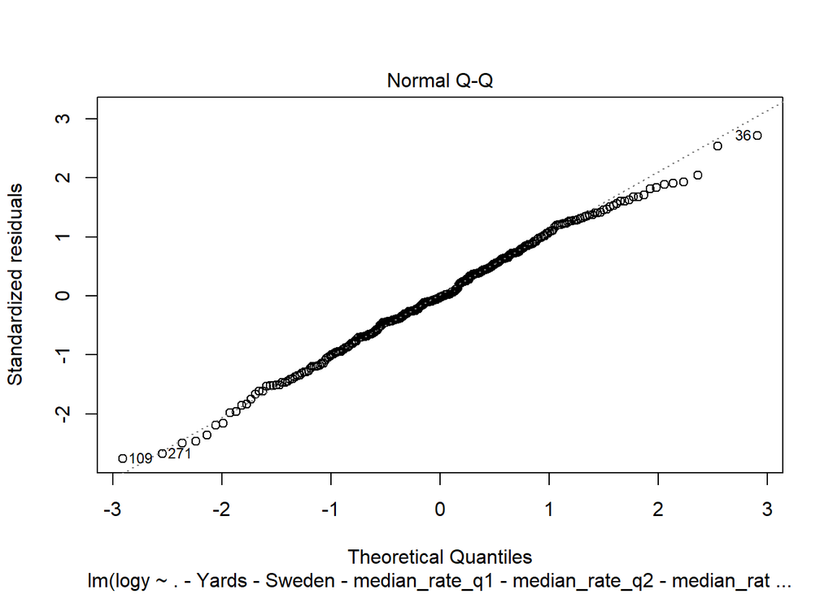

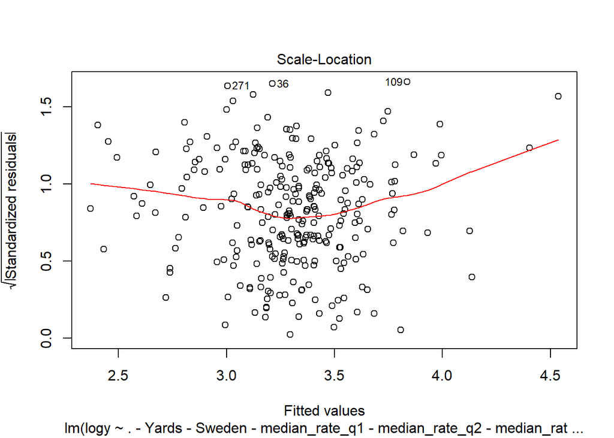

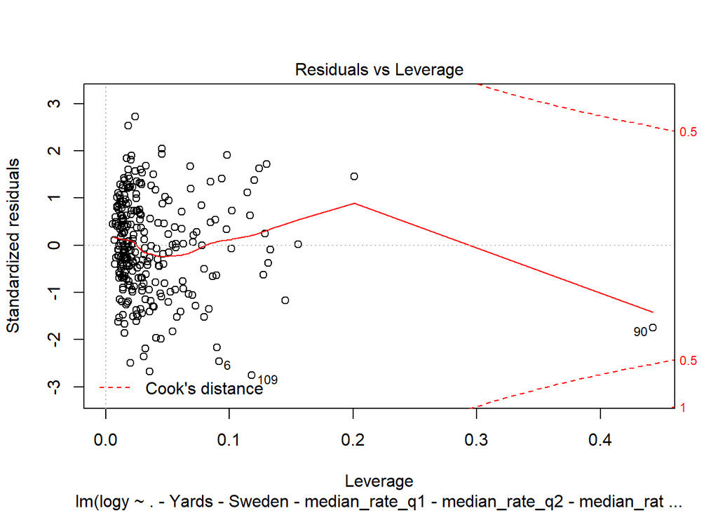

```r
plot(fit.lm.15)
```

```r
vif(fit.lm.15)
```

```
## avg_rate_q4       sd_q1       sd_q3       sd_q4  avg_sec_q3    range_q1
##    1.603754   13.917163   14.038583   11.609651    2.212188   13.973823
##    range_q3    range_q4  MinSeconds
##   15.585737   11.359852    3.663547
```

The Above is the final model all parameters are significant. Use GLM fit in order to do cross validation. During initial validation the interaction effects were kept in, and because they’re categorical the LOOCV had to be used to ensure all countries were included in each validation step. If we had done any type of training split it’s possible that some countries could have been excluded. Once the interaction effects were removed, the LOOCV was still kept as the validation method.

```r
fit.glm = glm(logy ~ .
                - Yards
                -Sweden
              - median_rate_q1
              - median_rate_q2
              - median_rate_q3
              - median_rate_q4
              - median_sec_q1
             - median_sec_q2
              - median_sec_q3
              - median_sec_q4
              - avg_rate_q1
              - avg_rate_q2
              - avg_rate_q3
                -Russia
              - MaxSeconds
                -Finland
                -Canada
                -Ukraine
                -Switzerland
                -Denmark
              - difference
                -Belgium
                -Ireland
                -UK
                -Germany
                -France
                -NZ
                -US
                -Japan
                -Spain
                -Australia
                -Mexico
                -India
                -Singapore
                -Belarus
                - rate_sd1
                - rate_sd2
                -rate_sd3
                -rate_sd4
                -avg_sec_q2
               -avg_sec_q1
                -sd_q2
                - avg_sec_q4
              - range_q2
              ,data = df.filtered.2)
summary(fit.glm)
```

```
##
## Call:
## glm(formula = logy ~ . - Yards - Sweden - median_rate_q1 - median_rate_q2 -
##     median_rate_q3 - median_rate_q4 - median_sec_q1 - median_sec_q2 -
##     median_sec_q3 - median_sec_q4 - avg_rate_q1 - avg_rate_q2 -
##     avg_rate_q3 - Russia - MaxSeconds - Finland - Canada - Ukraine -
##     Switzerland - Denmark - difference - Belgium - Ireland -
##     UK - Germany - France - NZ - US - Japan - Spain - Australia -
##     Mexico - India - Singapore - Belarus - rate_sd1 - rate_sd2 -
##     rate_sd3 - rate_sd4 - avg_sec_q2 - avg_sec_q1 - sd_q2 - avg_sec_q4 -
##     range_q2, data = df.filtered.2)
##
## Deviance Residuals:
##      Min        1Q    Median        3Q       Max
## -0.44091  -0.11308  -0.00328   0.11933   0.45103
##
## Coefficients:
##               Estimate Std. Error t value Pr(>|t|)
## (Intercept)  3.391e+00  2.021e-01  16.782  < 2e-16 ***
## avg_rate_q4 -1.535e-03  2.712e-04  -5.659 3.91e-08 ***
## sd_q1       -6.134e-03  6.351e-04  -9.658  < 2e-16 ***
## sd_q3       -4.616e-03  6.182e-04  -7.468 1.16e-12 ***
## sd_q4       -3.394e-03  4.220e-04  -8.042 2.88e-14 ***
## avg_sec_q3  -3.268e-04  8.537e-05  -3.828 0.000161 ***
## range_q1     2.445e-03  2.205e-04  11.090  < 2e-16 ***
## range_q3     1.765e-03  2.195e-04   8.039 2.95e-14 ***
## range_q4     1.323e-03  1.489e-04   8.885  < 2e-16 ***
## MinSeconds   2.938e-04  7.721e-05   3.804 0.000176 ***
## ---
## Signif. codes:  0 '***' 0.001 '**' 0.01 '*' 0.05 '.' 0.1 ' ' 1
##
## (Dispersion parameter for gaussian family taken to be 0.02814089)
##
##     Null deviance: 34.3166  on 276  degrees of freedom
## Residual deviance:  7.5136  on 267  degrees of freedom
## AIC: -191.13
##
## Number of Fisher Scoring iterations: 2
```

```r
anova(fit.glm)
```

```
## Analysis of Deviance Table
##
## Model: gaussian, link: identity
##
## Response: logy
##
## Terms added sequentially (first to last)
##
##
##             Df Deviance Resid. Df Resid. Dev
## NULL                          276     34.317
## avg_rate_q4  1   7.1676       275     27.149
## sd_q1        1   0.0127       274     27.136
## sd_q3        1   0.2311       273     26.905
## sd_q4        1   0.8783       272     26.027
## avg_sec_q3   1   0.2969       271     25.730
## range_q1     1  12.9812       270     12.749
## range_q3     1   2.6830       269     10.066
## range_q4     1   2.1449       268      7.921
## MinSeconds   1   0.4073       267      7.514
```

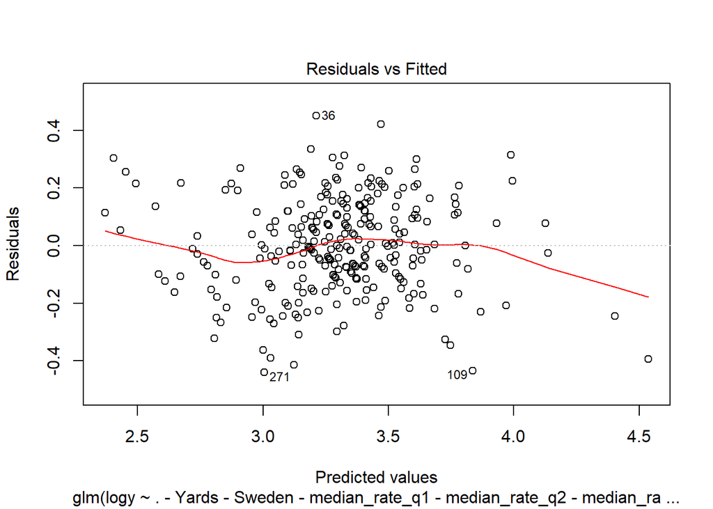

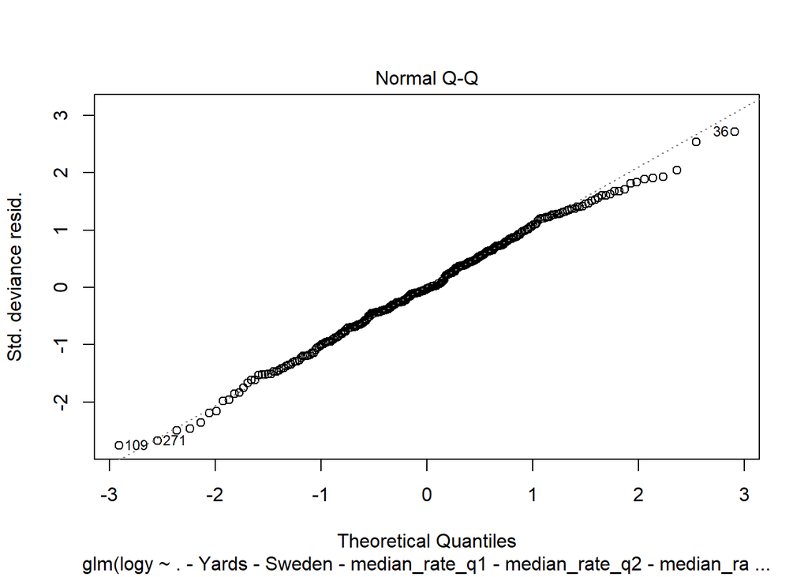

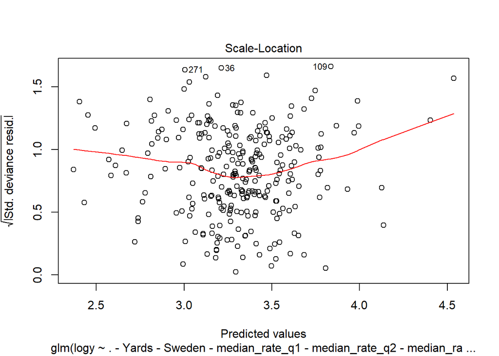

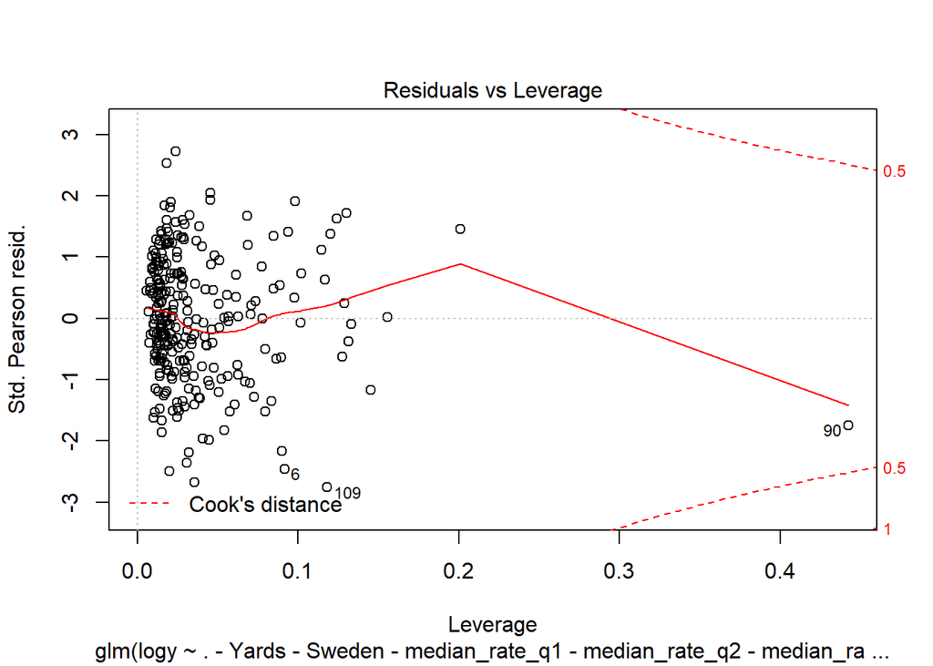

```r
plot(fit.glm)
```

```r
vif(fit.glm)
```

```
## avg_rate_q4       sd_q1       sd_q3       sd_q4  avg_sec_q3    range_q1
##    1.603754   13.917163   14.038583   11.609651    2.212188   13.973823
##    range_q3    range_q4  MinSeconds
##   15.585737   11.359852    3.663547
```

```r
library(boot)
cv.err = cv.glm(df.filtered.2, fit.glm)
cv.err$delta
```

```
## [1] 0.02993107 0.02992564
```

```r
for (j in 1:10) {
  error <- c()
  for (i in 1:nrow(df.filtered.2)) {
    model <- glm(logy ~ .
                - Yards
                -Sweden
              - median_rate_q1
              - median_rate_q2
              - median_rate_q3
              - median_rate_q4
              - median_sec_q1
             - median_sec_q2
              - median_sec_q3
              - median_sec_q4
              - avg_rate_q1
              - avg_rate_q2
              - avg_rate_q3
                -Russia
              - MaxSeconds
                -Finland
                -Canada
                -Ukraine
                -Switzerland
                -Denmark
                -Belgium
                -Ireland
             - difference
                -UK
                -Germany
                -France
                -NZ
                -US
                -Japan
                -Spain
                -Australia
                -Mexico
                -India
                -Singapore
                -Belarus
                - rate_sd1
                - rate_sd2
                -rate_sd3
                -rate_sd4
                -avg_sec_q2
                -avg_sec_q1
                -sd_q2
                - avg_sec_q4
              - range_q2, data = df.filtered.2[-i,])
    prediction <- predict(model, newdata = df.filtered.2[i,])
    error[i] <- (prediction - df.filtered.2[i, "logy"]) ^ 2
    if (i == nrow(df.filtered.2)) {
      LOOCV_MSE <- mean(error)
    }
  }
}
LOOCV_MSE
```

```
## [1] 0.02993107
```